# SLR and MLR

Todd Garner

2023-04-08

https://github.com/SMU-DataHub/CaseStudy2DDS/blob/main/Presentation_Frito_Lay.mp4

Link to my video

## This is the continuation of the analyses from Project_2.Rmd

For Multiple Linear Regression (MLR), I asked ChatGPT how many predictor values you could have in an MLR model. The answer was, as many as you want. But, with some caveats. They must all be numerical. (in addition to the other SLR/MLR variable constraints). It provided some guidance on how to cull down to only the most important features by using stepwise regression, regularization methods (Lasso and Ridge regression) or others to narrow down the model to the main features. The analysis below was done by code written by ChatGPT and was stepwise regression and bi-directional.

I performed a number of analyses using examples provided by ChatGPT that I have deleted.

```r
CS2_2 = readxl::read_excel(file.choose())
#View(CS2_2)
```

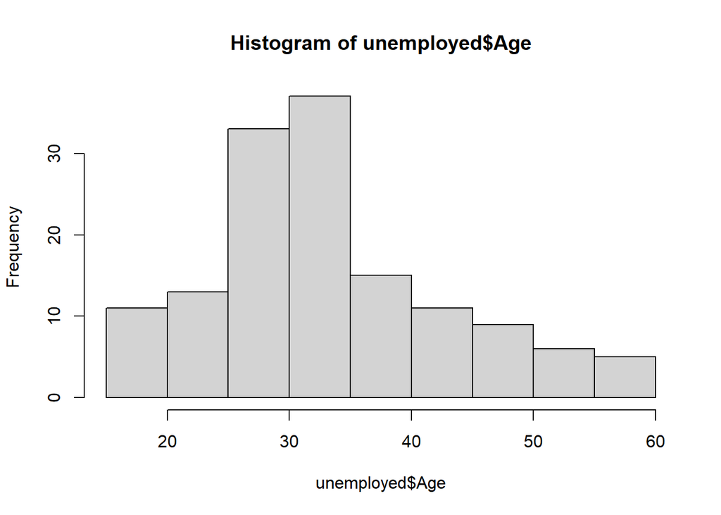

```r
employed <- CS2_2 %>% filter(Attrition == "No")
#View(employed)
employed <- CS2_2 %>% filter(Attrition == "No")
#View(employed)
unemployed <- CS2_2 %>% filter(Attrition == "Yes")
#View(unemployed)
tenure1 <- max(CS2_2$YearsAtCompany)
#tenure1

hist(unemployed$Age)
hist(unemployed$Age)
```

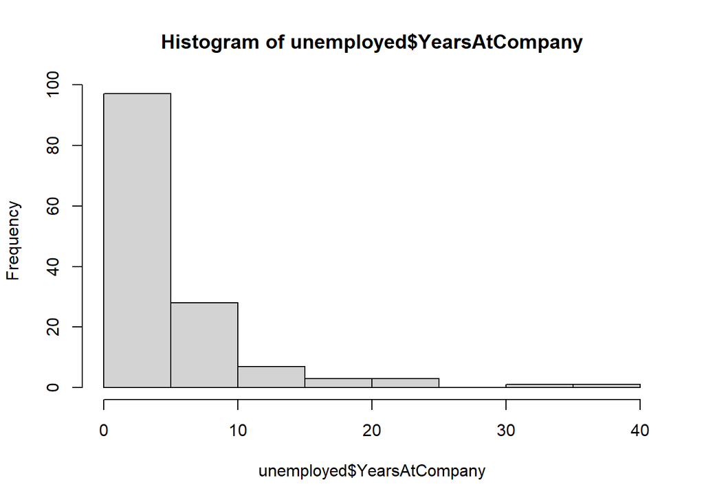

```r
hist(unemployed$YearsAtCompany)
```

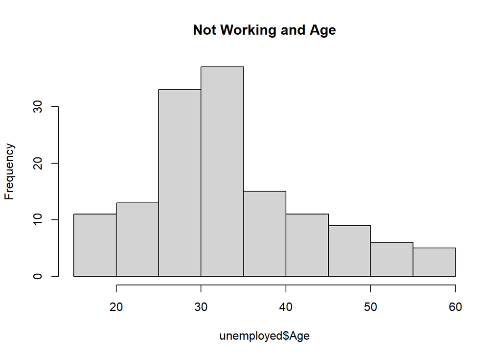

```r
hist(unemployed$Age, main = "Not Working and Age")
```

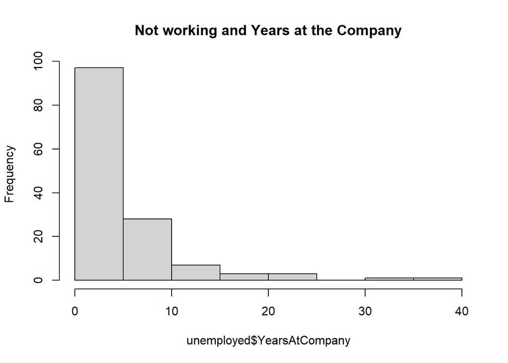

```r
hist(unemployed$YearsAtCompany, main = "Not working and Years at the Company")
```

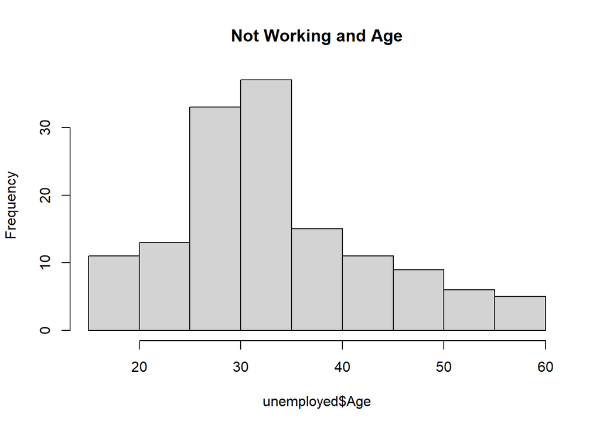

```r
hist(unemployed$Age, main = "Not Working and Age")
```

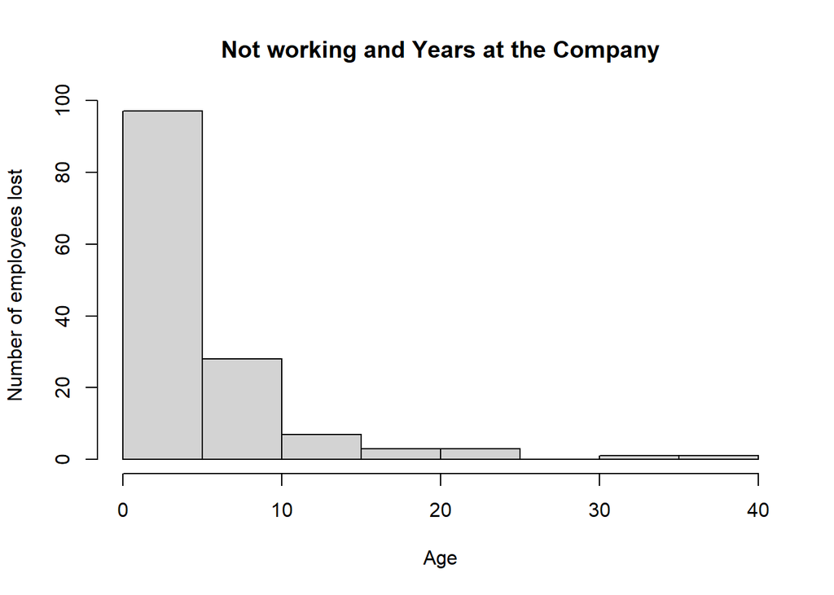

```r
hist(unemployed$YearsAtCompany, main = "Not working and Years at the Company", xlab = "Age", ylab = "Number of employees lost")
```

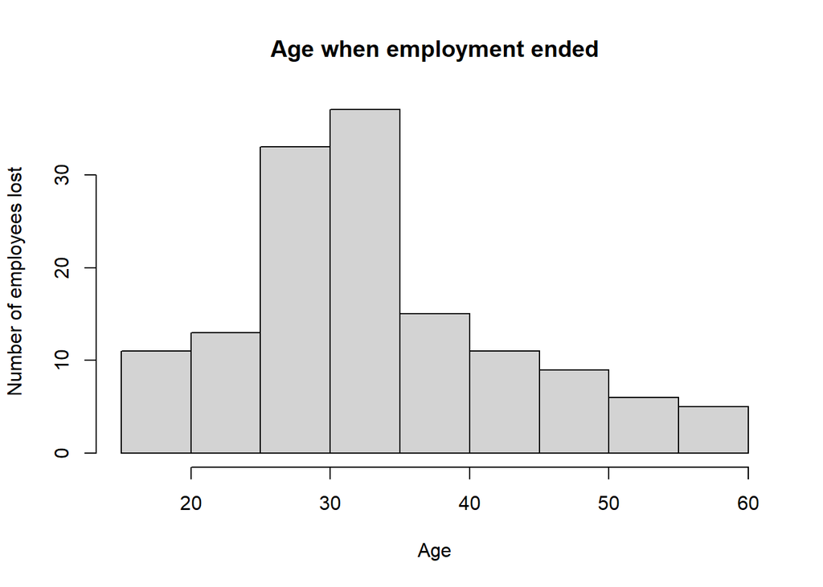

```r
hist(unemployed$Age, main = "Age when employment ended", xlab = "Age", ylab = "Number of employees lost")
```

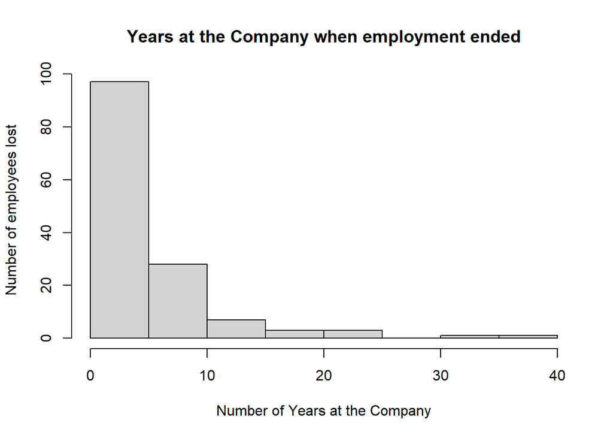

```r
hist(unemployed$YearsAtCompany, main = "Years at the Company when employment ended", xlab = "Number of Years at the Company", ylab = "Number of employees lost")
```

```r
summary(unemployed$Age)
```

```
##    Min. 1st Qu.  Median    Mean 3rd Qu.    Max.
##   18.00   28.00   32.00   33.79   39.00   58.00
```

```r
summary(unemployed$YearsAtCompany)
```

```
##    Min. 1st Qu.  Median    Mean 3rd Qu.    Max.
##   0.000   1.000   3.000   5.193   8.000  40.000
```

```r
t.test(unemployed$Age)
```

```
##
##  One Sample t-test
##
## data:  unemployed$Age
## t = 41.578, df = 139, p-value < 2.2e-16
## alternative hypothesis: true mean is not equal to 0
## 95 percent confidence interval:
##  32.17907 35.39235
## sample estimates:
## mean of x
##  33.78571
```

```r
t.test(unemployed$YearsAtCompany)
```

```
##
##  One Sample t-test
##
## data:  unemployed$YearsAtCompany
## t = 9.9562, df = 139, p-value < 2.2e-16
## alternative hypothesis: true mean is not equal to 0
## 95 percent confidence interval:
##  4.161622 6.224092
## sample estimates:
## mean of x
##  5.192857
```

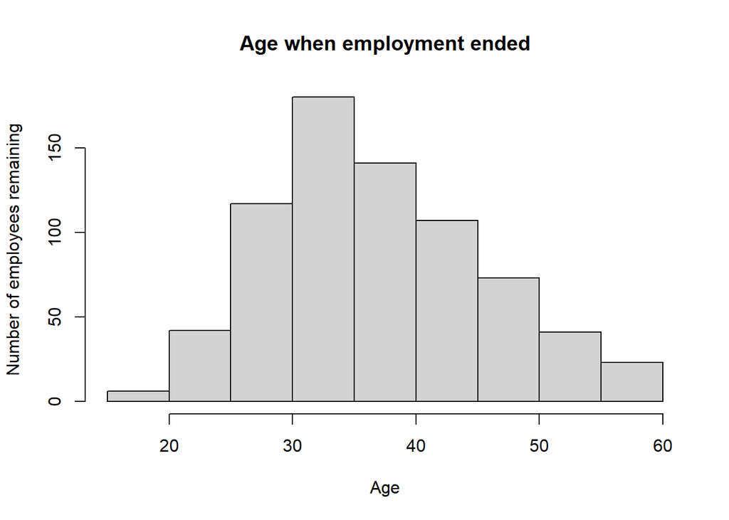

```r
hist(employed$Age, main = "Age when employment ended", xlab = "Age", ylab = "Number of employees remaining")
```

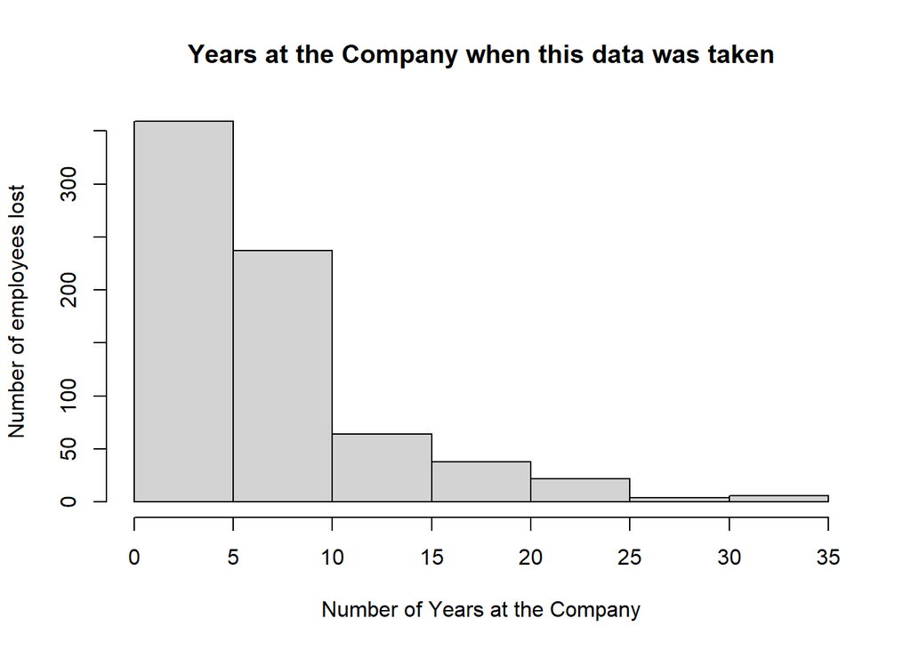

```r
hist(employed$YearsAtCompany, main = "Years at the Company when this data was taken", xlab = "Number of Years at the Company", ylab = "Number of employees lost")
```

```r
summary(employed$Age)
```

```
##    Min. 1st Qu.  Median    Mean 3rd Qu.    Max.
##   18.00   31.00   36.00   37.41   43.00   60.00
```

```r
summary(employed$YearsAtCompany)
```

```
##    Min. 1st Qu.  Median    Mean 3rd Qu.    Max.
##   0.000   3.000   6.000   7.301  10.000  33.000
```

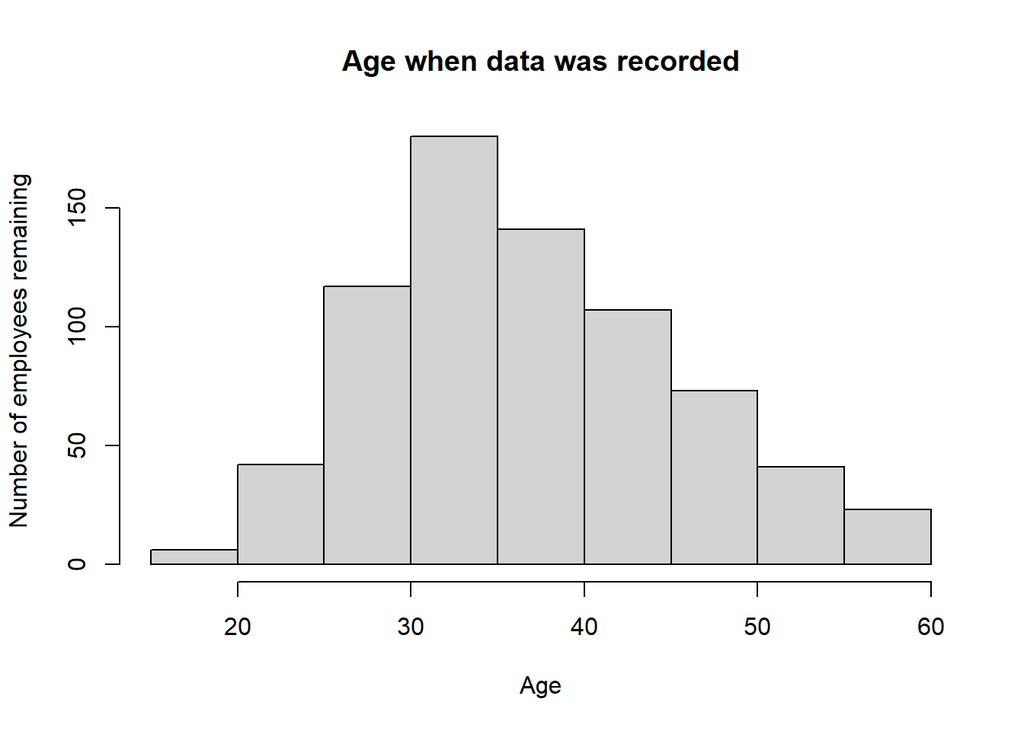

```r
hist(employed$Age, main = "Age when data was recorded", xlab = "Age", ylab = "Number of employees remaining")
```

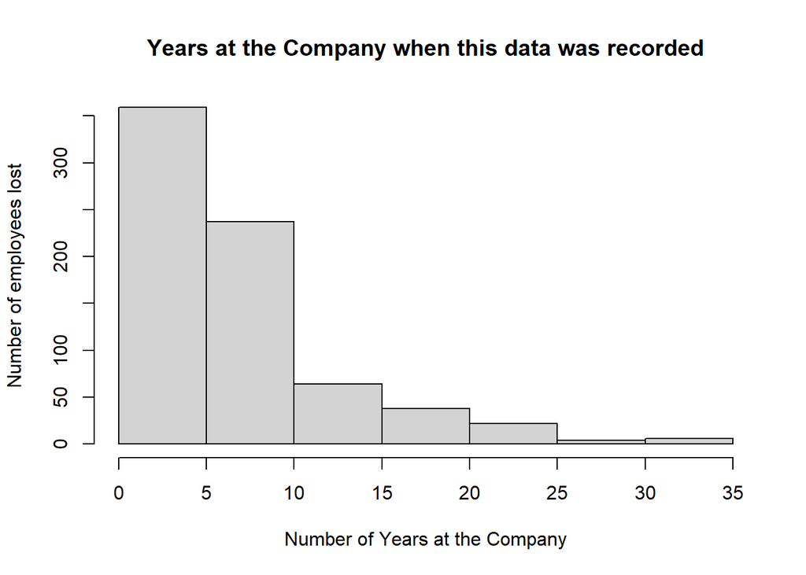

```r
hist(employed$YearsAtCompany, main = "Years at the Company when this data was recorded", xlab = "Number of Years at the Company", ylab = "Number of employees lost")
```

```r
summary(employed$Age)
```

```
##    Min. 1st Qu.  Median    Mean 3rd Qu.    Max.
##   18.00   31.00   36.00   37.41   43.00   60.00
```

```r
summary(employed$YearsAtCompany)
```

```
##    Min. 1st Qu.  Median    Mean 3rd Qu.    Max.
##   0.000   3.000   6.000   7.301  10.000  33.000
```

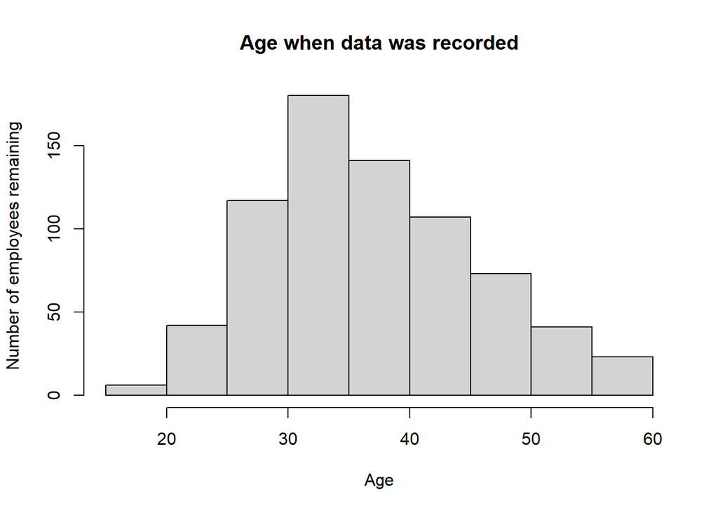

```r
hist(employed$Age, main = "Age when data was recorded", xlab = "Age", ylab = "Number of employees remaining")
```

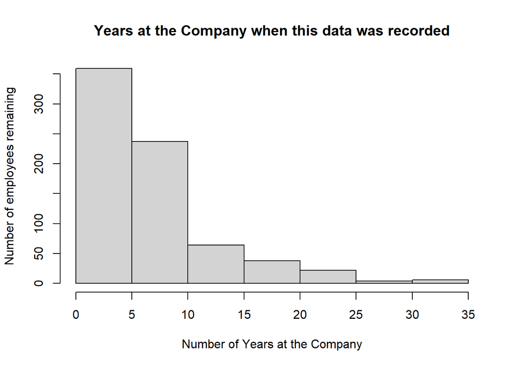

```r
hist(employed$YearsAtCompany, main = "Years at the Company when this data was recorded", xlab = "Number of Years at the Company", ylab = "Number of employees remaining")
```

```r
summary(employed$Age)
```

```
##    Min. 1st Qu.  Median    Mean 3rd Qu.    Max.
##   18.00   31.00   36.00   37.41   43.00   60.00
```

```r
summary(employed$YearsAtCompany)
```

```
##    Min. 1st Qu.  Median    Mean 3rd Qu.    Max.
##   0.000   3.000   6.000   7.301  10.000  33.000
```

```r
t.test(employed$Age)
```

```
##
##  One Sample t-test
##
## data:  employed$Age
## t = 116.54, df = 729, p-value < 2.2e-16
## alternative hypothesis: true mean is not equal to 0
## 95 percent confidence interval:
##  36.78210 38.04256
## sample estimates:
## mean of x
##  37.41233
```

```r
t.test(employed$YearsAtCompany)
```

```
##
##  One Sample t-test
##
## data:  employed$YearsAtCompany
## t = 33.233, df = 729, p-value < 2.2e-16
## alternative hypothesis: true mean is not equal to 0
## 95 percent confidence interval:
##  6.870042 7.732697
## sample estimates:
## mean of x
##   7.30137
```

We have three useful data sets. CS2_2 - all data, employed - those employees still working at Frito Lay, unemployed - those employees that have left the company. Unemployed could include fired, resigned, died, retired. I can’t think of any other reasons, but I don’t think that’s relevant.

I plotted all of the histograms and got the summary() for the unemployed data set with with each variable on the X axis and the count on the Y axis. Those were saved as PDF’s. A few were notable but we need more data analysis.

```r
KNN_2 <- CS2_2
View(KNN_2)
```

```r
summary(KNN_2)
```

```
##        ID             Age         Attrition         BusinessTravel
##  Min.   :  1.0   Min.   :18.00   Length:870         Length:870
##  1st Qu.:218.2   1st Qu.:30.00   Class :character   Class :character
##  Median :435.5   Median :35.00   Mode  :character   Mode  :character
##  Mean   :435.5   Mean   :36.83
##  3rd Qu.:652.8   3rd Qu.:43.00
##  Max.   :870.0   Max.   :60.00
##    DailyRate       Department        DistanceFromHome   Education
##  Min.   : 103.0   Length:870         Min.   : 1.000   Min.   :1.000
##  1st Qu.: 472.5   Class :character   1st Qu.: 2.000   1st Qu.:2.000
##  Median : 817.5   Mode  :character   Median : 7.000   Median :3.000
##  Mean   : 815.2                      Mean   : 9.339   Mean   :2.901
##  3rd Qu.:1165.8                      3rd Qu.:14.000   3rd Qu.:4.000
##  Max.   :1499.0                      Max.   :29.000   Max.   :5.000
##  EducationField     EmployeeCount EmployeeNumber   EnvironmentSatisfaction
##  Length:870         Min.   :1     Min.   :   1.0   Min.   :1.000
##  Class :character   1st Qu.:1     1st Qu.: 477.2   1st Qu.:2.000
##  Mode  :character   Median :1     Median :1039.0   Median :3.000
##                     Mean   :1     Mean   :1029.8   Mean   :2.701
##                     3rd Qu.:1     3rd Qu.:1561.5   3rd Qu.:4.000
##                     Max.   :1     Max.   :2064.0   Max.   :4.000
##     Gender            HourlyRate     JobInvolvement     JobLevel
##  Length:870         Min.   : 30.00   Min.   :1.000   Min.   :1.000
##  Class :character   1st Qu.: 48.00   1st Qu.:2.000   1st Qu.:1.000
##  Mode  :character   Median : 66.00   Median :3.000   Median :2.000
##                     Mean   : 65.61   Mean   :2.723   Mean   :2.039
##                     3rd Qu.: 83.00   3rd Qu.:3.000   3rd Qu.:3.000
##                     Max.   :100.00   Max.   :4.000   Max.   :5.000
##    JobRole          JobSatisfaction MaritalStatus      MonthlyIncome
##  Length:870         Min.   :1.000   Length:870         Min.   : 1081
##  Class :character   1st Qu.:2.000   Class :character   1st Qu.: 2840
##  Mode  :character   Median :3.000   Mode  :character   Median : 4946
##                     Mean   :2.709                      Mean   : 6390
##                     3rd Qu.:4.000                      3rd Qu.: 8182
##                     Max.   :4.000                      Max.   :19999
##   MonthlyRate    NumCompaniesWorked    Over18            OverTime
##  Min.   : 2094   Min.   :0.000      Length:870         Length:870
##  1st Qu.: 8092   1st Qu.:1.000      Class :character   Class :character
##  Median :14074   Median :2.000      Mode  :character   Mode  :character
##  Mean   :14326   Mean   :2.728
```

[output cut: 15 more lines]

```
##  Max.   :3.0000   Max.   :40.00     Max.   :6.000         Max.   :4.000
##  YearsAtCompany   YearsInCurrentRole YearsSinceLastPromotion
##  Min.   : 0.000   Min.   : 0.000     Min.   : 0.000
##  1st Qu.: 3.000   1st Qu.: 2.000     1st Qu.: 0.000
##  Median : 5.000   Median : 3.000     Median : 1.000
##  Mean   : 6.962   Mean   : 4.205     Mean   : 2.169
##  3rd Qu.:10.000   3rd Qu.: 7.000     3rd Qu.: 3.000
##  Max.   :40.000   Max.   :18.000     Max.   :15.000
##  YearsWithCurrManager
##  Min.   : 0.00
##  1st Qu.: 2.00
##  Median : 3.00
##  Mean   : 4.14
##  3rd Qu.: 7.00
##  Max.   :17.00
```

```r
sum(is.na(KNN_2))
```

```
## [1] 0
```

```r
#convert binary columns to 1s and 0s.
KNN_2$Attrition <- str_replace(KNN_2$Attrition,"No", "1")
KNN_2$Attrition <- str_replace(KNN_2$Attrition,"Yes", "0")
#KNN_2$Attrition
KNN_2$Gender <- str_replace(KNN_2$Gender,"Female", "1")
KNN_2$Gender <- str_replace(KNN_2$Gender,"Male", "0")
#KNN_2$Gender
KNN_2$OverTime <- str_replace(KNN_2$OverTime,"Yes", "1")
KNN_2$OverTime <- str_replace(KNN_2$OverTime,"No", "0")
#KNN_2$OverTime
KNN_2$MaritalStatus <- str_replace(KNN_2$MaritalStatus,"Single", "0")
KNN_2$MaritalStatus <- str_replace(KNN_2$MaritalStatus,"Divorced", "0")
KNN_2$MaritalStatus <- str_replace(KNN_2$MaritalStatus,"Married", "1")
#KNN_2$MaritalStatus

#[NOTE: THIS IS WHERE I NEED TO FACTORIZE THESE PREDICTORS AND KEEP THEM IN THE MODEL.]
#Instead of removing them, I need to factorize each of these predictors:
#View(KNN_2)
KNN_2$BusinessTravel <- factor(KNN_2$BusinessTravel)
KNN_2$Department <- factor(KNN_2$Department)
KNN_2$EducationField <- factor(KNN_2$EducationField)
KNN_2$JobRole <- factor(KNN_2$JobRole)
#KNN_2$Attrition <- factor(KNN_2$Attrition)
#KNN_2$Gender <- factor(KNN_2$Gender)
#KNN_2$OverTime <- factor(KNN_2$OverTime)
#KNN_2$MaritalStatus <- factor(KNN_2$MaritalStatus)

#View(KNN_2)
summary(KNN_2)
```

```
##        ID             Age         Attrition                   BusinessTravel
##  Min.   :  1.0   Min.   :18.00   Length:870         Non-Travel       : 94
##  1st Qu.:218.2   1st Qu.:30.00   Class :character   Travel_Frequently:158
##  Median :435.5   Median :35.00   Mode  :character   Travel_Rarely    :618
##  Mean   :435.5   Mean   :36.83
##  3rd Qu.:652.8   3rd Qu.:43.00
##  Max.   :870.0   Max.   :60.00
##
##    DailyRate                       Department  DistanceFromHome   Education
##  Min.   : 103.0   Human Resources       : 35   Min.   : 1.000   Min.   :1.000
##  1st Qu.: 472.5   Research & Development:562   1st Qu.: 2.000   1st Qu.:2.000
##  Median : 817.5   Sales                 :273   Median : 7.000   Median :3.000
##  Mean   : 815.2                                Mean   : 9.339   Mean   :2.901
##  3rd Qu.:1165.8                                3rd Qu.:14.000   3rd Qu.:4.000
##  Max.   :1499.0                                Max.   :29.000   Max.   :5.000
##
##           EducationField EmployeeCount EmployeeNumber   EnvironmentSatisfaction
##  Human Resources : 15    Min.   :1     Min.   :   1.0   Min.   :1.000
##  Life Sciences   :358    1st Qu.:1     1st Qu.: 477.2   1st Qu.:2.000
##  Marketing       :100    Median :1     Median :1039.0   Median :3.000
##  Medical         :270    Mean   :1     Mean   :1029.8   Mean   :2.701
##  Other           : 52    3rd Qu.:1     3rd Qu.:1561.5   3rd Qu.:4.000
##  Technical Degree: 75    Max.   :1     Max.   :2064.0   Max.   :4.000
##
##     Gender            HourlyRate     JobInvolvement     JobLevel
##  Length:870         Min.   : 30.00   Min.   :1.000   Min.   :1.000
##  Class :character   1st Qu.: 48.00   1st Qu.:2.000   1st Qu.:1.000
##  Mode  :character   Median : 66.00   Median :3.000   Median :2.000
##                     Mean   : 65.61   Mean   :2.723   Mean   :2.039
##                     3rd Qu.: 83.00   3rd Qu.:3.000   3rd Qu.:3.000
##                     Max.   :100.00   Max.   :4.000   Max.   :5.000
##
##                       JobRole    JobSatisfaction MaritalStatus
##  Sales Executive          :200   Min.   :1.000   Length:870
##  Research Scientist       :172   1st Qu.:2.000   Class :character
##  Laboratory Technician    :153   Median :3.000   Mode  :character
##  Manufacturing Director   : 87   Mean   :2.709
##  Healthcare Representative: 76   3rd Qu.:4.000
##  Sales Representative     : 53   Max.   :4.000
##  (Other)                  :129
```

[output cut: 25 more lines]

```
##  Min.   :0.000         Min.   :1.000   Min.   : 0.000   Min.   : 0.000
##  1st Qu.:2.000         1st Qu.:2.000   1st Qu.: 3.000   1st Qu.: 2.000
##  Median :3.000         Median :3.000   Median : 5.000   Median : 3.000
##  Mean   :2.832         Mean   :2.782   Mean   : 6.962   Mean   : 4.205
##  3rd Qu.:3.000         3rd Qu.:3.000   3rd Qu.:10.000   3rd Qu.: 7.000
##  Max.   :6.000         Max.   :4.000   Max.   :40.000   Max.   :18.000
##
##  YearsSinceLastPromotion YearsWithCurrManager
##  Min.   : 0.000          Min.   : 0.00
##  1st Qu.: 0.000          1st Qu.: 2.00
##  Median : 1.000          Median : 3.00
##  Mean   : 2.169          Mean   : 4.14
##  3rd Qu.: 3.000          3rd Qu.: 7.00
##  Max.   :15.000          Max.   :17.00
##
```

```r
#Remove the BusinessTravel, Department, EducationField, JobRole, MaritalStatus columns.
#KNN_2[ , c('BusinessTravel', 'Department', 'EducationField', 'JobRole', 'MaritalStatus')] <- list(NULL)
#View(KNN_2)
KNN_2[ , c('Over18', 'EmployeeCount', 'StandardHours')] <- list(NULL)
#View(KNN_2)
summary(KNN_2)
```

```
##        ID             Age         Attrition                   BusinessTravel
##  Min.   :  1.0   Min.   :18.00   Length:870         Non-Travel       : 94
##  1st Qu.:218.2   1st Qu.:30.00   Class :character   Travel_Frequently:158
##  Median :435.5   Median :35.00   Mode  :character   Travel_Rarely    :618
##  Mean   :435.5   Mean   :36.83
##  3rd Qu.:652.8   3rd Qu.:43.00
##  Max.   :870.0   Max.   :60.00
##
##    DailyRate                       Department  DistanceFromHome   Education
##  Min.   : 103.0   Human Resources       : 35   Min.   : 1.000   Min.   :1.000
##  1st Qu.: 472.5   Research & Development:562   1st Qu.: 2.000   1st Qu.:2.000
##  Median : 817.5   Sales                 :273   Median : 7.000   Median :3.000
##  Mean   : 815.2                                Mean   : 9.339   Mean   :2.901
##  3rd Qu.:1165.8                                3rd Qu.:14.000   3rd Qu.:4.000
##  Max.   :1499.0                                Max.   :29.000   Max.   :5.000
##
##           EducationField EmployeeNumber   EnvironmentSatisfaction
##  Human Resources : 15    Min.   :   1.0   Min.   :1.000
##  Life Sciences   :358    1st Qu.: 477.2   1st Qu.:2.000
##  Marketing       :100    Median :1039.0   Median :3.000
##  Medical         :270    Mean   :1029.8   Mean   :2.701
##  Other           : 52    3rd Qu.:1561.5   3rd Qu.:4.000
##  Technical Degree: 75    Max.   :2064.0   Max.   :4.000
##
##     Gender            HourlyRate     JobInvolvement     JobLevel
##  Length:870         Min.   : 30.00   Min.   :1.000   Min.   :1.000
##  Class :character   1st Qu.: 48.00   1st Qu.:2.000   1st Qu.:1.000
##  Mode  :character   Median : 66.00   Median :3.000   Median :2.000
##                     Mean   : 65.61   Mean   :2.723   Mean   :2.039
##                     3rd Qu.: 83.00   3rd Qu.:3.000   3rd Qu.:3.000
##                     Max.   :100.00   Max.   :4.000   Max.   :5.000
##
##                       JobRole    JobSatisfaction MaritalStatus
##  Sales Executive          :200   Min.   :1.000   Length:870
##  Research Scientist       :172   1st Qu.:2.000   Class :character
##  Laboratory Technician    :153   Median :3.000   Mode  :character
##  Manufacturing Director   : 87   Mean   :2.709
##  Healthcare Representative: 76   3rd Qu.:4.000
##  Sales Representative     : 53   Max.   :4.000
##  (Other)                  :129
```

[output cut: 17 more lines]

```
##  Min.   : 0.00     Min.   :0.000         Min.   :1.000   Min.   : 0.000
##  1st Qu.: 6.00     1st Qu.:2.000         1st Qu.:2.000   1st Qu.: 3.000
##  Median :10.00     Median :3.000         Median :3.000   Median : 5.000
##  Mean   :11.05     Mean   :2.832         Mean   :2.782   Mean   : 6.962
##  3rd Qu.:15.00     3rd Qu.:3.000         3rd Qu.:3.000   3rd Qu.:10.000
##  Max.   :40.00     Max.   :6.000         Max.   :4.000   Max.   :40.000
##
##  YearsInCurrentRole YearsSinceLastPromotion YearsWithCurrManager
##  Min.   : 0.000     Min.   : 0.000          Min.   : 0.00
##  1st Qu.: 2.000     1st Qu.: 0.000          1st Qu.: 2.00
##  Median : 3.000     Median : 1.000          Median : 3.00
##  Mean   : 4.205     Mean   : 2.169          Mean   : 4.14
##  3rd Qu.: 7.000     3rd Qu.: 3.000          3rd Qu.: 7.00
##  Max.   :18.000     Max.   :15.000          Max.   :17.00
##
```

We need to convert all character columns to numeric

```r
KNN_2$Attrition <- as.numeric(KNN_2$Attrition)
KNN_2$Gender <- as.numeric(KNN_2$Gender)
KNN_2$OverTime <- as.numeric(KNN_2$OverTime)
KNN_2$MaritalStatus <- as.numeric(KNN_2$MaritalStatus)

summary(KNN_2)
```

```
##        ID             Age          Attrition                BusinessTravel
##  Min.   :  1.0   Min.   :18.00   Min.   :0.0000   Non-Travel       : 94
##  1st Qu.:218.2   1st Qu.:30.00   1st Qu.:1.0000   Travel_Frequently:158
##  Median :435.5   Median :35.00   Median :1.0000   Travel_Rarely    :618
##  Mean   :435.5   Mean   :36.83   Mean   :0.8391
##  3rd Qu.:652.8   3rd Qu.:43.00   3rd Qu.:1.0000
##  Max.   :870.0   Max.   :60.00   Max.   :1.0000
##
##    DailyRate                       Department  DistanceFromHome   Education
##  Min.   : 103.0   Human Resources       : 35   Min.   : 1.000   Min.   :1.000
##  1st Qu.: 472.5   Research & Development:562   1st Qu.: 2.000   1st Qu.:2.000
##  Median : 817.5   Sales                 :273   Median : 7.000   Median :3.000
##  Mean   : 815.2                                Mean   : 9.339   Mean   :2.901
##  3rd Qu.:1165.8                                3rd Qu.:14.000   3rd Qu.:4.000
##  Max.   :1499.0                                Max.   :29.000   Max.   :5.000
##
##           EducationField EmployeeNumber   EnvironmentSatisfaction
##  Human Resources : 15    Min.   :   1.0   Min.   :1.000
##  Life Sciences   :358    1st Qu.: 477.2   1st Qu.:2.000
##  Marketing       :100    Median :1039.0   Median :3.000
##  Medical         :270    Mean   :1029.8   Mean   :2.701
##  Other           : 52    3rd Qu.:1561.5   3rd Qu.:4.000
##  Technical Degree: 75    Max.   :2064.0   Max.   :4.000
##
##      Gender         HourlyRate     JobInvolvement     JobLevel
##  Min.   :0.0000   Min.   : 30.00   Min.   :1.000   Min.   :1.000
##  1st Qu.:0.0000   1st Qu.: 48.00   1st Qu.:2.000   1st Qu.:1.000
##  Median :0.0000   Median : 66.00   Median :3.000   Median :2.000
##  Mean   :0.4069   Mean   : 65.61   Mean   :2.723   Mean   :2.039
##  3rd Qu.:1.0000   3rd Qu.: 83.00   3rd Qu.:3.000   3rd Qu.:3.000
##  Max.   :1.0000   Max.   :100.00   Max.   :4.000   Max.   :5.000
##
##                       JobRole    JobSatisfaction MaritalStatus
##  Sales Executive          :200   Min.   :1.000   Min.   :0.0000
##  Research Scientist       :172   1st Qu.:2.000   1st Qu.:0.0000
##  Laboratory Technician    :153   Median :3.000   Median :0.0000
##  Manufacturing Director   : 87   Mean   :2.709   Mean   :0.4713
##  Healthcare Representative: 76   3rd Qu.:4.000   3rd Qu.:1.0000
##  Sales Representative     : 53   Max.   :4.000   Max.   :1.0000
##  (Other)                  :129
```

[output cut: 17 more lines]

```
##  Min.   : 0.00     Min.   :0.000         Min.   :1.000   Min.   : 0.000
##  1st Qu.: 6.00     1st Qu.:2.000         1st Qu.:2.000   1st Qu.: 3.000
##  Median :10.00     Median :3.000         Median :3.000   Median : 5.000
##  Mean   :11.05     Mean   :2.832         Mean   :2.782   Mean   : 6.962
##  3rd Qu.:15.00     3rd Qu.:3.000         3rd Qu.:3.000   3rd Qu.:10.000
##  Max.   :40.00     Max.   :6.000         Max.   :4.000   Max.   :40.000
##
##  YearsInCurrentRole YearsSinceLastPromotion YearsWithCurrManager
##  Min.   : 0.000     Min.   : 0.000          Min.   : 0.00
##  1st Qu.: 2.000     1st Qu.: 0.000          1st Qu.: 2.00
##  Median : 3.000     Median : 1.000          Median : 3.00
##  Mean   : 4.205     Mean   : 2.169          Mean   : 4.14
##  3rd Qu.: 7.000     3rd Qu.: 3.000          3rd Qu.: 7.00
##  Max.   :18.000     Max.   :15.000          Max.   :17.00
##
```

```r
str(KNN_2)
```

```
## tibble [870 × 33] (S3: tbl_df/tbl/data.frame)
##  $ ID                      : num [1:870] 1 2 3 4 5 6 7 8 9 10 ...
##  $ Age                     : num [1:870] 32 40 35 32 24 27 41 37 34 34 ...
##  $ Attrition               : num [1:870] 1 1 1 1 1 1 1 1 1 1 ...
##  $ BusinessTravel          : Factor w/ 3 levels "Non-Travel","Travel_Frequently",..: 3 3 2 3 2 2 3 3 3 2 ...
##  $ DailyRate               : num [1:870] 117 1308 200 801 567 ...
##  $ Department              : Factor w/ 3 levels "Human Resources",..: 3 2 2 3 2 2 2 3 3 2 ...
##  $ DistanceFromHome        : num [1:870] 13 14 18 1 2 10 5 10 10 10 ...
##  $ Education               : num [1:870] 4 3 2 4 1 2 5 4 4 4 ...
##  $ EducationField          : Factor w/ 6 levels "Human Resources",..: 2 4 2 3 6 2 4 2 2 6 ...
##  $ EmployeeNumber          : num [1:870] 859 1128 1412 2016 1646 ...
##  $ EnvironmentSatisfaction : num [1:870] 2 3 3 3 1 4 2 4 3 4 ...
##  $ Gender                  : num [1:870] 0 0 0 1 1 0 0 1 1 0 ...
##  $ HourlyRate              : num [1:870] 73 44 60 48 32 32 90 88 87 92 ...
##  $ JobInvolvement          : num [1:870] 3 2 3 3 3 3 4 2 3 2 ...
```

[output cut: 19 more lines]

All columns are numeric or factors. R will substitute factors with dummy variables (per ChatGPT). Now, we MAY need to scale some columns, but I’m going to attempt to run the lm() without scaling to aid in interpretability.

```r
KNN_2$Attrition <- as.numeric(KNN_2$Attrition)
KNN_2$Gender <- as.numeric(KNN_2$Gender)
KNN_2$OverTime <- as.numeric(KNN_2$OverTime)
summary(KNN_2)
```

```
##        ID             Age          Attrition                BusinessTravel
##  Min.   :  1.0   Min.   :18.00   Min.   :0.0000   Non-Travel       : 94
##  1st Qu.:218.2   1st Qu.:30.00   1st Qu.:1.0000   Travel_Frequently:158
##  Median :435.5   Median :35.00   Median :1.0000   Travel_Rarely    :618
##  Mean   :435.5   Mean   :36.83   Mean   :0.8391
##  3rd Qu.:652.8   3rd Qu.:43.00   3rd Qu.:1.0000
##  Max.   :870.0   Max.   :60.00   Max.   :1.0000
##
##    DailyRate                       Department  DistanceFromHome   Education
##  Min.   : 103.0   Human Resources       : 35   Min.   : 1.000   Min.   :1.000
##  1st Qu.: 472.5   Research & Development:562   1st Qu.: 2.000   1st Qu.:2.000
##  Median : 817.5   Sales                 :273   Median : 7.000   Median :3.000
##  Mean   : 815.2                                Mean   : 9.339   Mean   :2.901
##  3rd Qu.:1165.8                                3rd Qu.:14.000   3rd Qu.:4.000
##  Max.   :1499.0                                Max.   :29.000   Max.   :5.000
##
##           EducationField EmployeeNumber   EnvironmentSatisfaction
##  Human Resources : 15    Min.   :   1.0   Min.   :1.000
##  Life Sciences   :358    1st Qu.: 477.2   1st Qu.:2.000
##  Marketing       :100    Median :1039.0   Median :3.000
##  Medical         :270    Mean   :1029.8   Mean   :2.701
##  Other           : 52    3rd Qu.:1561.5   3rd Qu.:4.000
##  Technical Degree: 75    Max.   :2064.0   Max.   :4.000
##
##      Gender         HourlyRate     JobInvolvement     JobLevel
##  Min.   :0.0000   Min.   : 30.00   Min.   :1.000   Min.   :1.000
##  1st Qu.:0.0000   1st Qu.: 48.00   1st Qu.:2.000   1st Qu.:1.000
##  Median :0.0000   Median : 66.00   Median :3.000   Median :2.000
##  Mean   :0.4069   Mean   : 65.61   Mean   :2.723   Mean   :2.039
##  3rd Qu.:1.0000   3rd Qu.: 83.00   3rd Qu.:3.000   3rd Qu.:3.000
##  Max.   :1.0000   Max.   :100.00   Max.   :4.000   Max.   :5.000
##
##                       JobRole    JobSatisfaction MaritalStatus
##  Sales Executive          :200   Min.   :1.000   Min.   :0.0000
##  Research Scientist       :172   1st Qu.:2.000   1st Qu.:0.0000
##  Laboratory Technician    :153   Median :3.000   Median :0.0000
##  Manufacturing Director   : 87   Mean   :2.709   Mean   :0.4713
##  Healthcare Representative: 76   3rd Qu.:4.000   3rd Qu.:1.0000
##  Sales Representative     : 53   Max.   :4.000   Max.   :1.0000
##  (Other)                  :129
```

[output cut: 17 more lines]

```
##  Min.   : 0.00     Min.   :0.000         Min.   :1.000   Min.   : 0.000
##  1st Qu.: 6.00     1st Qu.:2.000         1st Qu.:2.000   1st Qu.: 3.000
##  Median :10.00     Median :3.000         Median :3.000   Median : 5.000
##  Mean   :11.05     Mean   :2.832         Mean   :2.782   Mean   : 6.962
##  3rd Qu.:15.00     3rd Qu.:3.000         3rd Qu.:3.000   3rd Qu.:10.000
##  Max.   :40.00     Max.   :6.000         Max.   :4.000   Max.   :40.000
##
##  YearsInCurrentRole YearsSinceLastPromotion YearsWithCurrManager
##  Min.   : 0.000     Min.   : 0.000          Min.   : 0.00
##  1st Qu.: 2.000     1st Qu.: 0.000          1st Qu.: 2.00
##  Median : 3.000     Median : 1.000          Median : 3.00
##  Mean   : 4.205     Mean   : 2.169          Mean   : 4.14
##  3rd Qu.: 7.000     3rd Qu.: 3.000          3rd Qu.: 7.00
##  Max.   :18.000     Max.   :15.000          Max.   :17.00
##
```

```r
str(KNN_2)
```

```
## tibble [870 × 33] (S3: tbl_df/tbl/data.frame)
##  $ ID                      : num [1:870] 1 2 3 4 5 6 7 8 9 10 ...
##  $ Age                     : num [1:870] 32 40 35 32 24 27 41 37 34 34 ...
##  $ Attrition               : num [1:870] 1 1 1 1 1 1 1 1 1 1 ...
##  $ BusinessTravel          : Factor w/ 3 levels "Non-Travel","Travel_Frequently",..: 3 3 2 3 2 2 3 3 3 2 ...
##  $ DailyRate               : num [1:870] 117 1308 200 801 567 ...
##  $ Department              : Factor w/ 3 levels "Human Resources",..: 3 2 2 3 2 2 2 3 3 2 ...
##  $ DistanceFromHome        : num [1:870] 13 14 18 1 2 10 5 10 10 10 ...
##  $ Education               : num [1:870] 4 3 2 4 1 2 5 4 4 4 ...
##  $ EducationField          : Factor w/ 6 levels "Human Resources",..: 2 4 2 3 6 2 4 2 2 6 ...
##  $ EmployeeNumber          : num [1:870] 859 1128 1412 2016 1646 ...
##  $ EnvironmentSatisfaction : num [1:870] 2 3 3 3 1 4 2 4 3 4 ...
##  $ Gender                  : num [1:870] 0 0 0 1 1 0 0 1 1 0 ...
##  $ HourlyRate              : num [1:870] 73 44 60 48 32 32 90 88 87 92 ...
##  $ JobInvolvement          : num [1:870] 3 2 3 3 3 3 4 2 3 2 ...
```

[output cut: 19 more lines]

Now the KNN_2 data.frame is ready for analysis.

```r
splitPerc = .75
Full_set_2 = KNN_2 %>% filter(Attrition == "1" | Attrition == "0")
trainInices_2 = sample(1:dim(Full_set_2)[1],round(splitPerc * dim(Full_set_2)[1]))
train_2 = Full_set_2[trainInices_2,]
test_2 = Full_set_2[-trainInices_2,]
```

```r
summary(train_2)
```

```
##        ID             Age          Attrition                BusinessTravel
##  Min.   :  1.0   Min.   :18.00   Min.   :0.0000   Non-Travel       : 63
##  1st Qu.:214.8   1st Qu.:30.00   1st Qu.:1.0000   Travel_Frequently:120
##  Median :424.5   Median :36.00   Median :1.0000   Travel_Rarely    :469
##  Mean   :428.5   Mean   :36.89   Mean   :0.8344
##  3rd Qu.:641.2   3rd Qu.:43.00   3rd Qu.:1.0000
##  Max.   :870.0   Max.   :60.00   Max.   :1.0000
##
##    DailyRate                       Department  DistanceFromHome   Education
##  Min.   : 103.0   Human Resources       : 23   Min.   : 1.000   Min.   :1.0
##  1st Qu.: 487.5   Research & Development:418   1st Qu.: 2.000   1st Qu.:2.0
##  Median : 850.5   Sales                 :211   Median : 7.000   Median :3.0
##  Mean   : 825.9                                Mean   : 9.497   Mean   :2.9
##  3rd Qu.:1180.0                                3rd Qu.:15.000   3rd Qu.:4.0
##  Max.   :1499.0                                Max.   :29.000   Max.   :5.0
##
##           EducationField EmployeeNumber   EnvironmentSatisfaction
##  Human Resources : 10    Min.   :   1.0   Min.   :1.000
##  Life Sciences   :273    1st Qu.: 479.8   1st Qu.:2.000
##  Marketing       : 79    Median :1007.5   Median :3.000
##  Medical         :203    Mean   :1022.6   Mean   :2.678
##  Other           : 35    3rd Qu.:1577.8   3rd Qu.:4.000
##  Technical Degree: 52    Max.   :2064.0   Max.   :4.000
##
##      Gender         HourlyRate     JobInvolvement     JobLevel
##  Min.   :0.0000   Min.   : 30.00   Min.   :1.000   Min.   :1.000
##  1st Qu.:0.0000   1st Qu.: 48.00   1st Qu.:2.000   1st Qu.:1.000
##  Median :0.0000   Median : 66.00   Median :3.000   Median :2.000
##  Mean   :0.4264   Mean   : 65.52   Mean   :2.733   Mean   :2.041
##  3rd Qu.:1.0000   3rd Qu.: 83.00   3rd Qu.:3.000   3rd Qu.:3.000
##  Max.   :1.0000   Max.   :100.00   Max.   :4.000   Max.   :5.000
##
##                       JobRole    JobSatisfaction MaritalStatus
##  Sales Executive          :152   Min.   :1.000   Min.   :0.0000
##  Research Scientist       :131   1st Qu.:2.000   1st Qu.:0.0000
##  Laboratory Technician    :117   Median :3.000   Median :0.0000
##  Manufacturing Director   : 63   Mean   :2.701   Mean   :0.4755
##  Healthcare Representative: 48   3rd Qu.:4.000   3rd Qu.:1.0000
##  Manager                  : 47   Max.   :4.000   Max.   :1.0000
##  (Other)                  : 94
```

[output cut: 17 more lines]

```
##  Min.   : 0.00     Min.   :0.000         Min.   :1.000   Min.   : 0.000
##  1st Qu.: 6.00     1st Qu.:2.000         1st Qu.:2.000   1st Qu.: 2.000
##  Median :10.00     Median :3.000         Median :3.000   Median : 5.000
##  Mean   :11.16     Mean   :2.804         Mean   :2.775   Mean   : 6.906
##  3rd Qu.:15.00     3rd Qu.:3.000         3rd Qu.:3.000   3rd Qu.:10.000
##  Max.   :40.00     Max.   :6.000         Max.   :4.000   Max.   :40.000
##
##  YearsInCurrentRole YearsSinceLastPromotion YearsWithCurrManager
##  Min.   : 0.000     Min.   : 0.000          Min.   : 0.000
##  1st Qu.: 2.000     1st Qu.: 0.000          1st Qu.: 1.000
##  Median : 3.000     Median : 1.000          Median : 3.000
##  Mean   : 4.086     Mean   : 2.164          Mean   : 3.951
##  3rd Qu.: 7.000     3rd Qu.: 3.000          3rd Qu.: 7.000
##  Max.   :18.000     Max.   :15.000          Max.   :17.000
##
```

```r
summary(test_2)
```

```
##        ID             Age          Attrition                BusinessTravel
##  Min.   :  4.0   Min.   :18.00   Min.   :0.0000   Non-Travel       : 31
##  1st Qu.:229.2   1st Qu.:30.00   1st Qu.:1.0000   Travel_Frequently: 38
##  Median :481.0   Median :35.00   Median :1.0000   Travel_Rarely    :149
##  Mean   :456.4   Mean   :36.65   Mean   :0.8532
##  3rd Qu.:680.0   3rd Qu.:43.00   3rd Qu.:1.0000
##  Max.   :867.0   Max.   :59.00   Max.   :1.0000
##
##    DailyRate                       Department  DistanceFromHome   Education
##  Min.   : 111.0   Human Resources       : 12   Min.   : 1.000   Min.   :1.000
##  1st Qu.: 465.0   Research & Development:144   1st Qu.: 2.000   1st Qu.:2.000
##  Median : 777.5   Sales                 : 62   Median : 7.000   Median :3.000
##  Mean   : 783.2                                Mean   : 8.867   Mean   :2.904
##  3rd Qu.:1136.8                                3rd Qu.:14.000   3rd Qu.:4.000
##  Max.   :1488.0                                Max.   :29.000   Max.   :5.000
##
##           EducationField EmployeeNumber   EnvironmentSatisfaction
##  Human Resources : 5     Min.   :  14.0   Min.   :1.000
##  Life Sciences   :85     1st Qu.: 477.2   1st Qu.:2.000
##  Marketing       :21     Median :1118.5   Median :3.000
##  Medical         :67     Mean   :1051.5   Mean   :2.771
##  Other           :17     3rd Qu.:1538.5   3rd Qu.:4.000
##  Technical Degree:23     Max.   :2026.0   Max.   :4.000
##
##      Gender         HourlyRate     JobInvolvement     JobLevel
##  Min.   :0.0000   Min.   : 30.00   Min.   :1.000   Min.   :1.000
##  1st Qu.:0.0000   1st Qu.: 50.25   1st Qu.:2.000   1st Qu.:1.000
##  Median :0.0000   Median : 66.00   Median :3.000   Median :2.000
##  Mean   :0.3486   Mean   : 65.89   Mean   :2.693   Mean   :2.032
##  3rd Qu.:1.0000   3rd Qu.: 84.00   3rd Qu.:3.000   3rd Qu.:3.000
##  Max.   :1.0000   Max.   :100.00   Max.   :4.000   Max.   :5.000
##
##                       JobRole   JobSatisfaction MaritalStatus
##  Sales Executive          :48   Min.   :1.000   Min.   :0.0000
##  Research Scientist       :41   1st Qu.:2.000   1st Qu.:0.0000
##  Laboratory Technician    :36   Median :3.000   Median :0.0000
##  Healthcare Representative:28   Mean   :2.734   Mean   :0.4587
##  Manufacturing Director   :24   3rd Qu.:4.000   3rd Qu.:1.0000
##  Research Director        :14   Max.   :4.000   Max.   :1.0000
##  (Other)                  :27
```

[output cut: 17 more lines]

```
##  Min.   : 0.00     Min.   :0.000         Min.   :1.000   Min.   : 0.000
##  1st Qu.: 6.00     1st Qu.:2.000         1st Qu.:3.000   1st Qu.: 3.000
##  Median : 9.00     Median :3.000         Median :3.000   Median : 6.000
##  Mean   :10.73     Mean   :2.917         Mean   :2.803   Mean   : 7.128
##  3rd Qu.:13.00     3rd Qu.:3.000         3rd Qu.:3.000   3rd Qu.:10.000
##  Max.   :37.00     Max.   :6.000         Max.   :4.000   Max.   :33.000
##
##  YearsInCurrentRole YearsSinceLastPromotion YearsWithCurrManager
##  Min.   : 0.00      Min.   : 0.000          Min.   : 0.000
##  1st Qu.: 2.00      1st Qu.: 0.000          1st Qu.: 2.000
##  Median : 3.00      Median : 1.000          Median : 3.500
##  Mean   : 4.56      Mean   : 2.183          Mean   : 4.706
##  3rd Qu.: 7.00      3rd Qu.: 2.000          3rd Qu.: 7.750
##  Max.   :16.00      Max.   :15.000          Max.   :17.000
##
```

```r
#View(train_2)
#View(test_2)
dim(train_2$Attrition)
```

```r
Only1_2 = train_2 %>% filter(Attrition == "1")
#Only1_2
```

Now we have a train & test set we can set up the KNN analysis.  
From here, everything is different as we will be using lm() multiple linear regression.

# MLR - the 7 key requirements:

1. The relationship between the independent and dependent variables is linear.
2. The distribution of the response for fixed values of the explanatory variables is normal.
3. The distribution of the residuals is normal.
4. The normal distributions of the response should have constant variance (standard deviation) for fixed values of the explanatory variables.
5. The normal distributions of the residuals should have constant variance (standard deviation) for fixed values of the explanatory variables.
6. Explanatory variables are independent of one another. (No multicollinearity).
7. Observations are independent of one another.

## Note, the following analyses have NOT been scaled at all. The multi-level predictors were converted into factors and R took care of assigning a dummy variable and handling the importance of each predictor level. All other predictors were transformed to numerical variables.

## An excellent way to see a step-by-step example of bidirectional stepwise regression (also known as stepwise regression with both forward selection and backward elimination) is to follow a tutorial or example using a popular programming language like R or Python.

I have used this method to attempt to cull the number of variables down to a reasonable size. Given the outcome, I’m not sure I’ve accomplished that. So, I’ll work another method.

## Install and load the ‘MASS’ package, which provides the ‘stepAIC()’ function for stepwise regression:

```r
library(MASS)
full_model <- lm(Attrition ~ ., data = KNN_2)
#Perform bidirectional stepwise regression using the 'stepAIC()' function:

stepwise_model <- stepAIC(full_model, direction = "both", trace = FALSE)
#The 'direction' argument set to "both" indicates that the stepwise regression should perform bidirectional elimination, and 'trace = #TRUE' will output the step-by-step process of adding or removing variables.

#Examine the final selected model:
summary(stepwise_model)
```

```
##
## Call:
## lm(formula = Attrition ~ Age + BusinessTravel + DistanceFromHome +
##     EnvironmentSatisfaction + JobInvolvement + JobRole + JobSatisfaction +
##     NumCompaniesWorked + OverTime + RelationshipSatisfaction +
##     StockOptionLevel + TotalWorkingYears + TrainingTimesLastYear +
##     WorkLifeBalance + YearsInCurrentRole + YearsSinceLastPromotion,
##     data = KNN_2)
##
## Residuals:
##      Min       1Q   Median       3Q      Max
## -1.11908 -0.07809  0.07561  0.20563  0.56242
##
## Coefficients:
##                                  Estimate Std. Error t value Pr(>|t|)
## (Intercept)                      0.199726   0.108789   1.836 0.066722 .
## Age                              0.003527   0.001650   2.138 0.032828 *
## BusinessTravelTravel_Frequently -0.110596   0.042376  -2.610 0.009218 **
## BusinessTravelTravel_Rarely     -0.049133   0.035838  -1.371 0.170745
## DistanceFromHome                -0.004050   0.001353  -2.994 0.002830 **
## EnvironmentSatisfaction          0.027690   0.010010   2.766 0.005796 **
## JobInvolvement                   0.085977   0.015671   5.486 5.43e-08 ***
## JobRoleHuman Resources          -0.086259   0.073548  -1.173 0.241197
## JobRoleLaboratory Technician    -0.058447   0.046718  -1.251 0.211260
## JobRoleManager                  -0.036104   0.062160  -0.581 0.561511
## JobRoleManufacturing Director    0.083390   0.050880   1.639 0.101595
## JobRoleResearch Director         0.049457   0.060349   0.820 0.412723
## JobRoleResearch Scientist       -0.011860   0.045790  -0.259 0.795692
## JobRoleSales Executive          -0.029922   0.043658  -0.685 0.493299
## JobRoleSales Representative     -0.249225   0.060695  -4.106 4.41e-05 ***
## JobSatisfaction                  0.042749   0.009865   4.333 1.65e-05 ***
## NumCompaniesWorked              -0.020300   0.004793  -4.236 2.53e-05 ***
## OverTime                        -0.209637   0.024320  -8.620  < 2e-16 ***
## RelationshipSatisfaction         0.022220   0.009941   2.235 0.025659 *
## StockOptionLevel                 0.048123   0.012835   3.749 0.000189 ***
## TotalWorkingYears                0.005517   0.002713   2.033 0.042326 *
## TrainingTimesLastYear            0.017675   0.008670   2.039 0.041784 *
## WorkLifeBalance                  0.040785   0.015463   2.638 0.008504 **
## YearsInCurrentRole               0.007924   0.003972   1.995 0.046384 *
## YearsSinceLastPromotion         -0.015591   0.004321  -3.609 0.000326 ***
## ---
## Signif. codes:  0 '***' 0.001 '**' 0.01 '*' 0.05 '.' 0.1 ' ' 1
##
## Residual standard error: 0.3195 on 845 degrees of freedom
## Multiple R-squared:  0.2658, Adjusted R-squared:  0.245
## F-statistic: 12.75 on 24 and 845 DF,  p-value: < 2.2e-16
```

```r
#This will give you a summary of the final stepwise regression model, including the selected predictor variables and their coefficients.
```

Call: lm(formula = Attrition ~ Age + BusinessTravel + DistanceFromHome + EnvironmentSatisfaction + JobInvolvement + JobRole + JobSatisfaction + NumCompaniesWorked + OverTime + RelationshipSatisfaction + StockOptionLevel + TotalWorkingYears + TrainingTimesLastYear + WorkLifeBalance + YearsInCurrentRole + YearsSinceLastPromotion, data = KNN_2)

Residuals: Min 1Q Median 3Q Max -1.11908 -0.07809 0.07561 0.20563 0.56242

Residual standard error: 0.3195 on 845 degrees of freedom Multiple R-squared: 0.2658, Adjusted R-squared: 0.245 F-statistic: 12.75 on 24 and 845 DF, p-value: < 2.2e-16

### Referring to the signficance codes, these are the top contributors 1s - highly, 2s - high, 3s almost high:

1 JobInvolvement 0.085977 0.015671 5.486 5.43e-08 ***  
1 JobRoleSales Representative -0.249225 0.060695 -4.106 4.41e-05 ***  
1 JobSatisfaction 0.042749 0.009865 4.333 1.65e-05 ***  
1 NumCompaniesWorked -0.020300 0.004793 -4.236 2.53e-05 ***  
1 OverTime -0.209637 0.024320 -8.620 < 2e-16 ***  
1 StockOptionLevel 0.048123 0.012835 3.749 0.000189 ***  
1 YearsSinceLastPromotion -0.015591 0.004321 -3.609 0.000326 ***  
2 BusinessTravelTravel_Frequently -0.110596 0.042376 -2.610 0.009218 **  
2 DistanceFromHome -0.004050 0.001353 -2.994 0.002830 **  
2 EnvironmentSatisfaction 0.027690 0.010010 2.766 0.005796 **  
2 WorkLifeBalance 0.040785 0.015463 2.638 0.008504 **  
3 Age 0.003527 0.001650 2.138 0.032828 *  
3 RelationshipSatisfaction 0.022220 0.009941 2.235 0.025659 *  
3 TotalWorkingYears 0.005517 0.002713 2.033 0.042326 *  
3 TrainingTimesLastYear 0.017675 0.008670 2.039 0.041784 *  
3 YearsInCurrentRole 0.007924 0.003972 1.995 0.046384 *

## Linear Regression Model 2 -

I’m going to run the same analysis using a standard multiple linear regression model as we’ve seen before.

```r
fit = lm(Attrition ~ ., data = KNN_2)
summary(fit)
```

```
##
## Call:
## lm(formula = Attrition ~ ., data = KNN_2)
##
## Residuals:
##      Min       1Q   Median       3Q      Max
## -1.10640 -0.08117  0.07610  0.20307  0.52952
##
## Coefficients:
##                                    Estimate Std. Error t value Pr(>|t|)
## (Intercept)                       1.867e-01  2.317e-01   0.806 0.420452
## ID                               -1.405e-05  4.481e-05  -0.314 0.753853
## Age                               3.255e-03  1.709e-03   1.904 0.057283 .
## BusinessTravelTravel_Frequently  -1.045e-01  4.293e-02  -2.434 0.015136 *
## BusinessTravelTravel_Rarely      -4.606e-02  3.658e-02  -1.259 0.208315
## DailyRate                         2.365e-05  2.772e-05   0.853 0.393814
## DepartmentResearch & Development -1.251e-01  1.446e-01  -0.865 0.387381
## DepartmentSales                  -1.443e-01  1.480e-01  -0.975 0.329698
## DistanceFromHome                 -4.152e-03  1.385e-03  -2.998 0.002796 **
## Education                         4.906e-03  1.129e-02   0.434 0.664075
## EducationFieldLife Sciences       2.115e-01  1.119e-01   1.890 0.059111 .
## EducationFieldMarketing           2.035e-01  1.187e-01   1.715 0.086707 .
## EducationFieldMedical             2.182e-01  1.121e-01   1.947 0.051893 .
## EducationFieldOther               2.106e-01  1.197e-01   1.760 0.078833 .
## EducationFieldTechnical Degree    1.389e-01  1.166e-01   1.191 0.234078
## EmployeeNumber                    1.446e-05  1.848e-05   0.782 0.434197
## EnvironmentSatisfaction           2.798e-02  1.017e-02   2.750 0.006090 **
## Gender                            1.485e-02  2.255e-02   0.659 0.510376
## HourlyRate                       -6.991e-04  5.530e-04  -1.264 0.206547
## JobInvolvement                    8.384e-02  1.590e-02   5.273 1.71e-07 ***
## JobLevel                          1.792e-02  3.886e-02   0.461 0.644897
## JobRoleHuman Resources           -1.398e-01  1.562e-01  -0.895 0.371028
## JobRoleLaboratory Technician     -7.153e-02  5.234e-02  -1.367 0.172103
## JobRoleManager                    1.556e-02  9.718e-02   0.160 0.872858
## JobRoleManufacturing Director     7.776e-02  5.145e-02   1.511 0.131072
## JobRoleResearch Director          7.837e-02  7.932e-02   0.988 0.323423
## JobRoleResearch Scientist        -1.642e-02  5.192e-02  -0.316 0.751903
## JobRoleSales Executive           -1.638e-02  1.088e-01  -0.151 0.880351
## JobRoleSales Representative      -2.343e-01  1.188e-01  -1.973 0.048787 *
## JobSatisfaction                   4.196e-02  1.003e-02   4.184 3.17e-05 ***
## MaritalStatus                     1.429e-02  2.292e-02   0.623 0.533150
## MonthlyIncome                    -8.333e-06  1.059e-05  -0.787 0.431422
## MonthlyRate                       9.383e-07  1.565e-06   0.599 0.549032
## NumCompaniesWorked               -2.145e-02  5.081e-03  -4.222 2.69e-05 ***
## OverTime                         -2.105e-01  2.453e-02  -8.578  < 2e-16 ***
## PercentSalaryHike                -1.759e-03  4.810e-03  -0.366 0.714755
## PerformanceRating                -1.463e-02  4.915e-02  -0.298 0.766033
## RelationshipSatisfaction          2.363e-02  1.010e-02   2.338 0.019606 *
## StockOptionLevel                  4.783e-02  1.329e-02   3.599 0.000339 ***
## TotalWorkingYears                 6.777e-03  3.370e-03   2.011 0.044672 *
## TrainingTimesLastYear             1.848e-02  8.826e-03   2.094 0.036591 *
## WorkLifeBalance                   4.159e-02  1.561e-02   2.664 0.007870 **
## YearsAtCompany                   -4.469e-03  4.153e-03  -1.076 0.282172
## YearsInCurrentRole                8.308e-03  5.186e-03   1.602 0.109536
## YearsSinceLastPromotion          -1.481e-02  4.633e-03  -3.197 0.001440 **
## YearsWithCurrManager              5.805e-03  5.060e-03   1.147 0.251567
## ---
## Signif. codes:  0 '***' 0.001 '**' 0.01 '*' 0.05 '.' 0.1 ' ' 1
##
## Residual standard error: 0.3206 on 824 degrees of freedom
## Multiple R-squared:  0.279,  Adjusted R-squared:  0.2396
## F-statistic: 7.084 on 45 and 824 DF,  p-value: < 2.2e-16
```

Call: lm(formula = Attrition ~ ., data = KNN_2)

Residuals: Min 1Q Median 3Q Max -1.10640 -0.08117 0.07610 0.20307 0.52952

Residual standard error: 0.3206 on 824 degrees of freedom Multiple R-squared: 0.279, Adjusted R-squared: 0.2396 F-statistic: 7.084 on 45 and 824 DF, p-value: < 2.2e-16

Referencing the significance codes once again:

```
JobInvolvement                    8.384e-02  1.590e-02   5.273 1.71e-07 ***
JobSatisfaction                   4.196e-02  1.003e-02   4.184 3.17e-05 ***
NumCompaniesWorked               -2.145e-02  5.081e-03  -4.222 2.69e-05 ***
OverTime                         -2.105e-01  2.453e-02  -8.578  < 2e-16 ***
StockOptionLevel                  4.783e-02  1.329e-02   3.599 0.000339 ***
DistanceFromHome                 -4.152e-03  1.385e-03  -2.998 0.002796 **
EnvironmentSatisfaction           2.798e-02  1.017e-02   2.750 0.006090 **
WorkLifeBalance                   4.159e-02  1.561e-02   2.664 0.007870 **
YearsSinceLastPromotion          -1.481e-02  4.633e-03  -3.197 0.001440 **
BusinessTravelTravel_Frequently  -1.045e-01  4.293e-02  -2.434 0.015136 *
JobRoleSales Representative      -2.343e-01  1.188e-01  -1.973 0.048787 *
RelationshipSatisfaction          2.363e-02  1.010e-02   2.338 0.019606 *
TotalWorkingYears                 6.777e-03  3.370e-03   2.011 0.044672 *
TrainingTimesLastYear             1.848e-02  8.826e-03   2.094 0.036591 *
```

## Narrowing down the analysis

There are a few variables that are common to both sets:

1. JobInvolvement
2. JobSatisfaction
3. NumCompaniesWorked
4. OverTime
5. StockOptionLevel

It makes sense to narrow the analysis to these few factors to see their effect and to get a better feel for which ones make the most impact.

Using standard Multiple Linear regression, I’ll focus on these variables. I will also test the 7 factors that must be adhered to in order for this analysis to be valid.

Before I dig into the 7 assumptions, I’m going to run these 5 variables only instead of the whole set.

```r
fit = lm(Attrition ~ JobInvolvement + JobSatisfaction + NumCompaniesWorked + OverTime + StockOptionLevel, data = KNN_2)
summary(fit)
```

```
##
## Call:
## lm(formula = Attrition ~ JobInvolvement + JobSatisfaction + NumCompaniesWorked +
##     OverTime + StockOptionLevel, data = KNN_2)
##
## Residuals:
##      Min       1Q   Median       3Q      Max
## -1.07477 -0.00566  0.09374  0.18965  0.57285
##
## Coefficients:
##                     Estimate Std. Error t value Pr(>|t|)
## (Intercept)         0.521312   0.058511   8.910  < 2e-16 ***
## JobInvolvement      0.091016   0.016539   5.503 4.92e-08 ***
## JobSatisfaction     0.040171   0.010442   3.847 0.000128 ***
## NumCompaniesWorked -0.008044   0.004612  -1.744 0.081468 .
## OverTime           -0.217308   0.025549  -8.506  < 2e-16 ***
## StockOptionLevel    0.058663   0.013547   4.330 1.66e-05 ***
## ---
## Signif. codes:  0 '***' 0.001 '**' 0.01 '*' 0.05 '.' 0.1 ' ' 1
##
## Residual standard error: 0.3415 on 864 degrees of freedom
## Multiple R-squared:  0.1425, Adjusted R-squared:  0.1375
## F-statistic: 28.71 on 5 and 864 DF,  p-value: < 2.2e-16
```

```r
preds = predict(fit)
#preds
```

Here is what we’ve got:

Call: lm(formula = Attrition ~ JobInvolvement + JobSatisfaction + NumCompaniesWorked + OverTime + StockOptionLevel, data = KNN_2)

Residuals: Min 1Q Median 3Q Max -1.07477 -0.00566 0.09374 0.18965 0.57285

Coefficients: Estimate Std. Error t value Pr(>|t|)  
(Intercept) 0.521312 0.058511 8.910 < 2e-16 *JobInvolvement 0.091016 0.016539 5.503 4.92e-08* JobSatisfaction 0.040171 0.010442 3.847 0.000128 NumCompaniesWorked -0.008044 0.004612 -1.744 0.081468 .  
OverTime -0.217308 0.025549 -8.506 < 2e-16 StockOptionLevel 0.058663 0.013547 4.330 1.66e-05 *** — Signif. codes: 0 ‘**’ 0.001 ‘**’ 0.01 ‘’ 0.05 ‘.’ 0.1 ‘ ’ 1

Residual standard error: 0.3415 on 864 degrees of freedom Multiple R-squared: 0.1425, Adjusted R-squared: 0.1375 F-statistic: 28.71 on 5 and 864 DF, p-value: < 2.2e-16

It would appear that NumCompaniesWorked has dropped out. Let’s run the same analysis with just these variables leaving out NumCompaniesWorked.

```r
fit = lm(Attrition ~ JobInvolvement + JobSatisfaction + OverTime + StockOptionLevel, data = KNN_2)
summary(fit)
```

```
##
## Call:
## lm(formula = Attrition ~ JobInvolvement + JobSatisfaction + OverTime +
##     StockOptionLevel, data = KNN_2)
##
## Residuals:
##      Min       1Q   Median       3Q      Max
## -1.10928  0.00648  0.09784  0.18903  0.58918
##
## Coefficients:
##                  Estimate Std. Error t value Pr(>|t|)
## (Intercept)       0.49533    0.05665   8.744  < 2e-16 ***
## JobInvolvement    0.09136    0.01656   5.518 4.54e-08 ***
## JobSatisfaction   0.04156    0.01042   3.987 7.26e-05 ***
## OverTime         -0.21743    0.02558  -8.501  < 2e-16 ***
## StockOptionLevel  0.05788    0.01356   4.270 2.17e-05 ***
## ---
## Signif. codes:  0 '***' 0.001 '**' 0.01 '*' 0.05 '.' 0.1 ' ' 1
##
## Residual standard error: 0.3419 on 865 degrees of freedom
## Multiple R-squared:  0.1395, Adjusted R-squared:  0.1355
## F-statistic: 35.05 on 4 and 865 DF,  p-value: < 2.2e-16
```

```r
unique(KNN_2$JobInvolvement)
```

```
## [1] 3 2 4 1
```

```r
unique(KNN_2$JobSatisfaction)
```

```
## [1] 4 3 1 2
```

```r
unique(KNN_2$OverTime)
```

```
## [1] 0 1
```

```r
unique(KNN_2$StockOptionLevel)
```

```
## [1] 1 0 2 3
```

```r
JI <- KNN_2$JobInvolvement
OT <- KNN_2$OverTime
SO <- KNN_2$StockOptionLevel

fit = lm(Attrition ~ JI + OT + SO, data = KNN_2)
summary(fit)
```

```
##
## Call:
## lm(formula = Attrition ~ JI + OT + SO, data = KNN_2)
##
## Residuals:
##      Min       1Q   Median       3Q      Max
## -1.05337  0.00429  0.11961  0.20757  0.51008
##
## Coefficients:
##             Estimate Std. Error t value Pr(>|t|)
## (Intercept)  0.61650    0.04821  12.787  < 2e-16 ***
## JI           0.08796    0.01668   5.275 1.68e-07 ***
## OT          -0.21454    0.02579  -8.320 3.41e-16 ***
## SO           0.05766    0.01367   4.218 2.73e-05 ***
## ---
## Signif. codes:  0 '***' 0.001 '**' 0.01 '*' 0.05 '.' 0.1 ' ' 1
##
## Residual standard error: 0.3448 on 866 degrees of freedom
## Multiple R-squared:  0.1237, Adjusted R-squared:  0.1206
## F-statistic: 40.73 on 3 and 866 DF,  p-value: < 2.2e-16
```

Call: lm(formula = Attrition ~ JobInvolvement + JobSatisfaction + OverTime + StockOptionLevel, data = KNN_2)

Residuals: Min 1Q Median 3Q Max -1.10928 0.00648 0.09784 0.18903 0.58918

Coefficients: Estimate Std. Error t value Pr(>|t|)  
(Intercept) 0.49533 0.05665 8.744 < 2e-16 *JobInvolvement 0.09136 0.01656 5.518 4.54e-08* JobSatisfaction 0.04156 0.01042 3.987 7.26e-05 *OverTime -0.21743 0.02558 -8.501 < 2e-16* StockOptionLevel 0.05788 0.01356 4.270 2.17e-05 *** — Signif. codes: 0 ‘**’ 0.001 ‘**’ 0.01 ‘’ 0.05 ‘.’ 0.1 ‘ ’ 1

Residual standard error: 0.3419 on 865 degrees of freedom Multiple R-squared: 0.1395, Adjusted R-squared: 0.1355 F-statistic: 35.05 on 4 and 865 DF, p-value: < 2.2e-16

Looking solely at the magnitude of the Estimate values for each variable, it would appear that these three factors contribute to Attrition:

Attrition = .49533 + .09136(JobInvolvement) - 0.21743(OverTime) + .05788(StockOptionLevel)

JobInvolvement is a non-defined variable with levels of 1 - 4 JobSatisfaction is a non-defined variable with levels of 1 - 4 OverTime is a somewhat non-defined variable with a level of 0 and 1 StockOptionLevel is a non-defined variable with a level of 0-3

This would likely make for an interesting ShinyApp plugging allowing these variables to be set by the user. Presumably, Attrition = 0 is not employed at the company anymore. Attrition = 1 means still employed. The Intercept at basically .5 makes sense and the other variables add or subtract from this level with greater than .5 meaning still working and less than .5 meaning not working.

To rename the variables and run the final factors:

```r
JI <- KNN_2$JobInvolvement
OT <- KNN_2$OverTime
SO <- KNN_2$StockOptionLevel

fit = lm(Attrition ~ JI + OT + SO, data = KNN_2)
summary(fit)
```

```
##
## Call:
## lm(formula = Attrition ~ JI + OT + SO, data = KNN_2)
##
## Residuals:
##      Min       1Q   Median       3Q      Max
## -1.05337  0.00429  0.11961  0.20757  0.51008
##
## Coefficients:
##             Estimate Std. Error t value Pr(>|t|)
## (Intercept)  0.61650    0.04821  12.787  < 2e-16 ***
## JI           0.08796    0.01668   5.275 1.68e-07 ***
## OT          -0.21454    0.02579  -8.320 3.41e-16 ***
## SO           0.05766    0.01367   4.218 2.73e-05 ***
## ---
## Signif. codes:  0 '***' 0.001 '**' 0.01 '*' 0.05 '.' 0.1 ' ' 1
##
## Residual standard error: 0.3448 on 866 degrees of freedom
## Multiple R-squared:  0.1237, Adjusted R-squared:  0.1206
## F-statistic: 40.73 on 3 and 866 DF,  p-value: < 2.2e-16
```

```r
preds = predict(fit)
#reds
```

Call: lm(formula = Attrition ~ JI + OT + SO, data = KNN_2)

Residuals: Min 1Q Median 3Q Max -1.05337 0.00429 0.11961 0.20757 0.51008

Coefficients: Estimate Std. Error t value Pr(>|t|)  
(Intercept) 0.61650 0.04821 12.787 < 2e-16 *JI 0.08796 0.01668 5.275 1.68e-07* OT -0.21454 0.02579 -8.320 3.41e-16 *SO 0.05766 0.01367 4.218 2.73e-05* — Signif. codes: 0 ‘**’ 0.001 ‘**’ 0.01 ‘’ 0.05 ‘.’ 0.1 ‘ ’ 1

Residual standard error: 0.3448 on 866 degrees of freedom Multiple R-squared: 0.1237, Adjusted R-squared: 0.1206 F-statistic: 40.73 on 3 and 866 DF, p-value: < 2.2e-16

# Attrition = .61650 - .21454(OT) + .08796(JI) + .05766(SO)

## This would indeed make for a great ShinyApp.

1. The relationship between the independent and dependent variables is linear.
2. The distribution of the response for fixed values of the explanatory variables is normal.
3. The distribution of the residuals is normal.
4. The normal distributions of the response should have constant variance (standard deviation) for fixed values of the explanatory variables.
5. The normal distributions of the residuals should have constant variance (standard deviation) for fixed values of the explanatory variables.
6. Explanatory variables are independent of one another. (No multicollinearity).
7. Observations are independent of one another.

##I asked ChatGPT how to evaluate these 7 factors. Here are the results:

1. Linearity: The relationship between the predictor variables and the target variable should be linear.

How to check:

Create scatter plots of each predictor variable against the target variable. Plot the residuals against the predicted values (fitted values).

```r
fit = lm(Attrition ~ JI + OT + SO, data = KNN_2)
summary(fit)
```

```
##
## Call:
## lm(formula = Attrition ~ JI + OT + SO, data = KNN_2)
##
## Residuals:
##      Min       1Q   Median       3Q      Max
## -1.05337  0.00429  0.11961  0.20757  0.51008
##
## Coefficients:
##             Estimate Std. Error t value Pr(>|t|)
## (Intercept)  0.61650    0.04821  12.787  < 2e-16 ***
## JI           0.08796    0.01668   5.275 1.68e-07 ***
## OT          -0.21454    0.02579  -8.320 3.41e-16 ***
## SO           0.05766    0.01367   4.218 2.73e-05 ***
## ---
## Signif. codes:  0 '***' 0.001 '**' 0.01 '*' 0.05 '.' 0.1 ' ' 1
##
## Residual standard error: 0.3448 on 866 degrees of freedom
## Multiple R-squared:  0.1237, Adjusted R-squared:  0.1206
## F-statistic: 40.73 on 3 and 866 DF,  p-value: < 2.2e-16
```

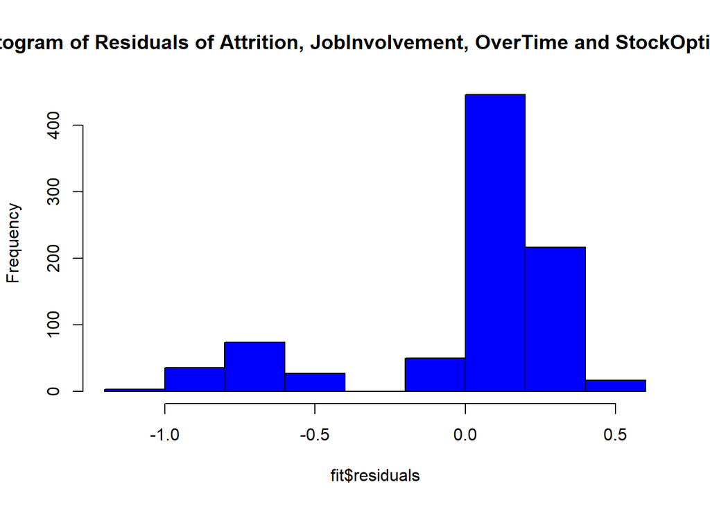

```r
preds = predict(fit)
fit = lm(Attrition~JI + OT +SO, data = KNN_2)
hist(fit$residuals, col = "blue", main = "Histogram of Residuals of Attrition, JobInvolvement, OverTime and StockOptionLevel")
```

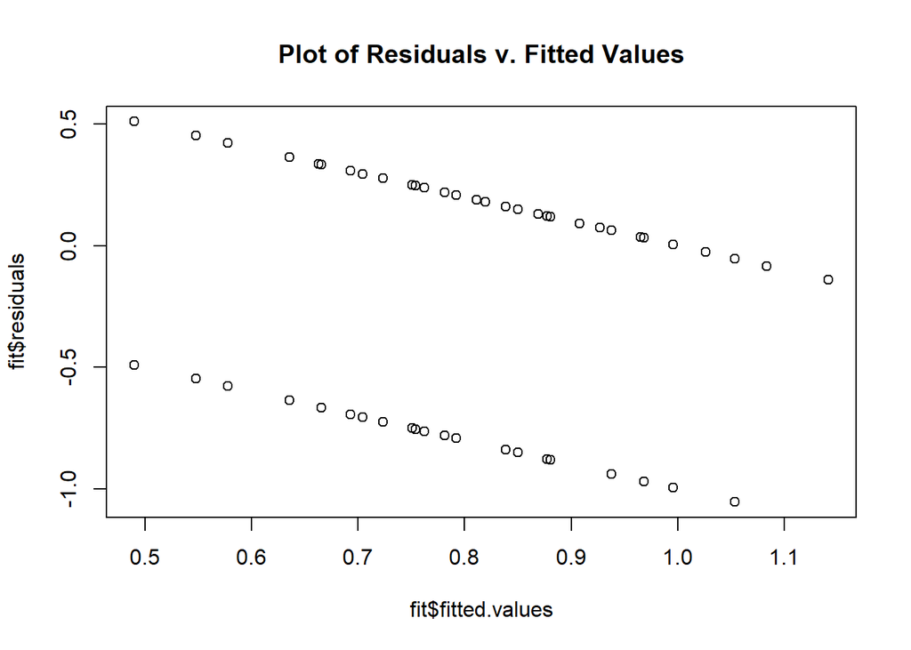

```r
plot(fit$fitted.values,fit$residuals, main = "Plot of Residuals v. Fitted Values")
```

```r
library(GGally)
```

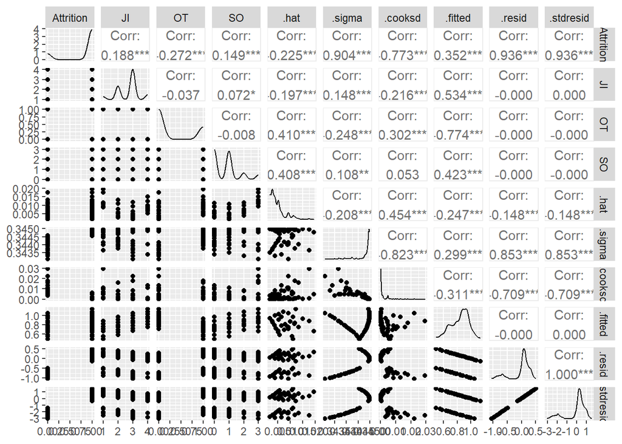

```r
fit %>% ggpairs()
```

This ggpairs plot shows much of what is shown below in many of the remaining steps. It appears that all but one variable appears to be valid with one in the questionable range, but not wildly out of balance.

How to check:

If you have time-series or spatial data, plot the data to see if there is any visible pattern or clustering. Use the Durbin-Watson test to detect autocorrelation in the residuals.

```r
#install.packages("car")
library(car)
durbinWatsonTest(fit)
```

```
##  lag Autocorrelation D-W Statistic p-value
##    1      0.01114613      1.977531    0.78
##  Alternative hypothesis: rho != 0
```

Since the p value is greater than .05, we cannot reject the null hypothesis that the residuals are not autocorrelated.

3. Homoscedasticity (constant variance) of residuals: The residuals should have constant variance across the range of predictor variables.

How to check:

Plot the residuals against the predicted values. Use formal tests, such as the Breusch-Pagan test or the White test, to detect heteroscedasticity.

```r
#install.packages("lmtest")
library(lmtest)
bptest(fit)
```

```
##
##  studentized Breusch-Pagan test
##
## data:  fit
## BP = 78.491, df = 3, p-value < 2.2e-16
```

bptest(fit)

```
studentized Breusch-Pagan test
```

data: fit BP = 78.491, df = 3, p-value < 2.2e-16

4. Normally distributed residuals: The residuals should follow a normal distribution.

How to check:

Create a histogram or density plot of the residuals. Create a Q-Q plot (quantile-quantile plot) to compare the distribution of the residuals to a normal distribution. Use formal tests, such as the *Shapiro-Wilk test* or the Kolmogorov-Smirnov test, to check for normality.

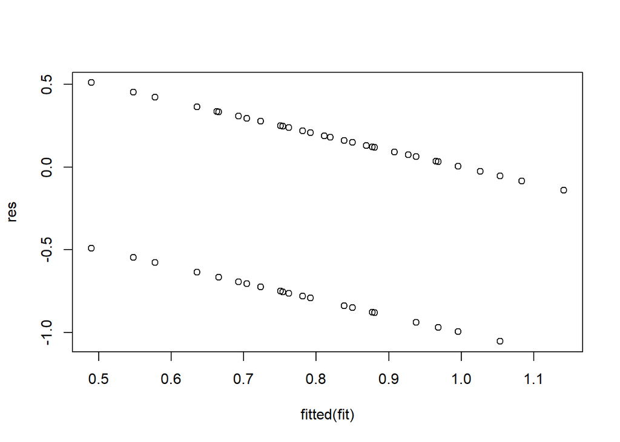

```r
res <- resid(fit)
plot(fitted(fit), res)
```

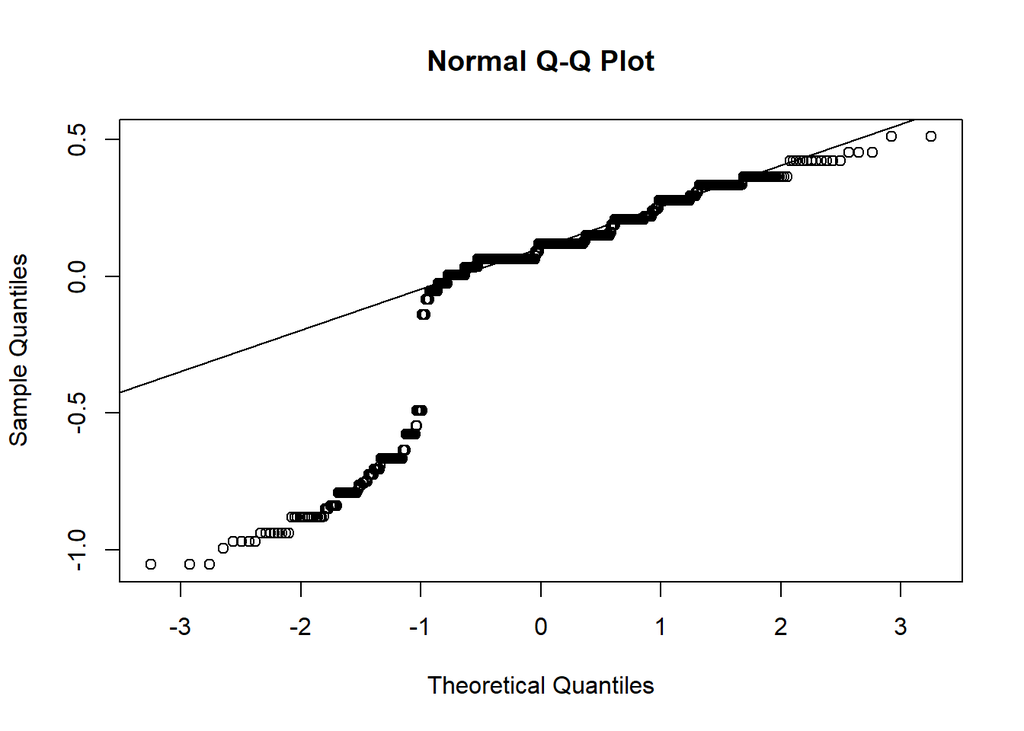

```r
qqnorm(res)
qqline(res)
```

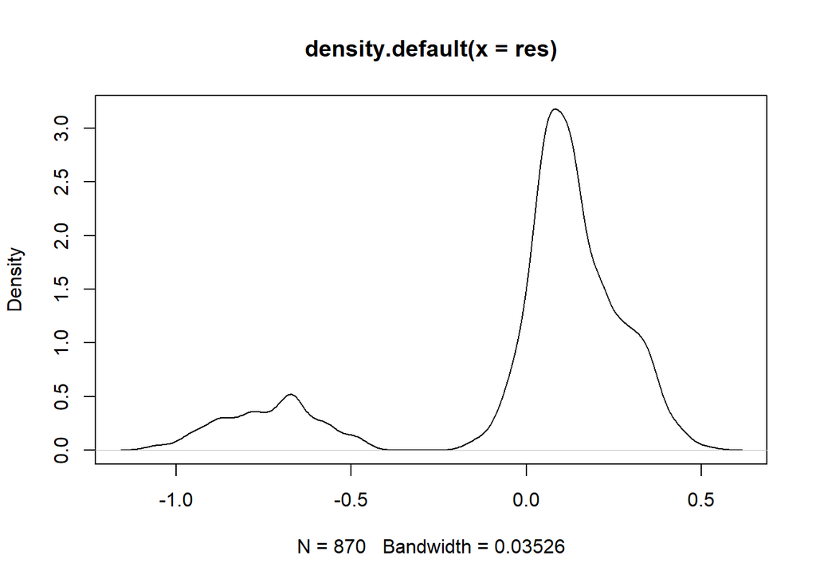

```r
plot(density(res))
```

5. No multicollinearity: Predictor variables should not be highly correlated with each other.

How to check:

Calculate the correlation matrix for the predictor variables. Calculate the variance inflation factor (VIF) for each predictor variable. VIF values greater than 10 indicate high multicollinearity.

#```{r} cor(KNN_2)

df <- cbind(KNN_2$Attrition, KNN_2$JobInvolvement, KNN_2$OverTime, KNN_2$StockOptionLevel)

library(Hmisc) rcorr(as.matrix(df))

#install.packages(“corrplot”) library(corrplot) corrplot(cor(df))

6. No influential outliers: The model should not be overly influenced by a few extreme data points.

How to check:

Create scatter plots of each predictor variable against the target variable to visually identify outliers. Use Cook’s distance or leverage values to detect influential points.

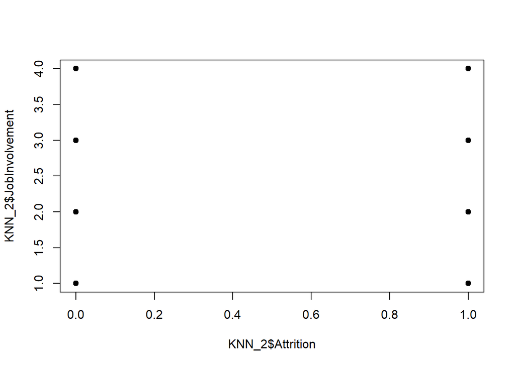

```r
plot(KNN_2$Attrition, KNN_2$JobInvolvement, pch = 19, col = "black")
```

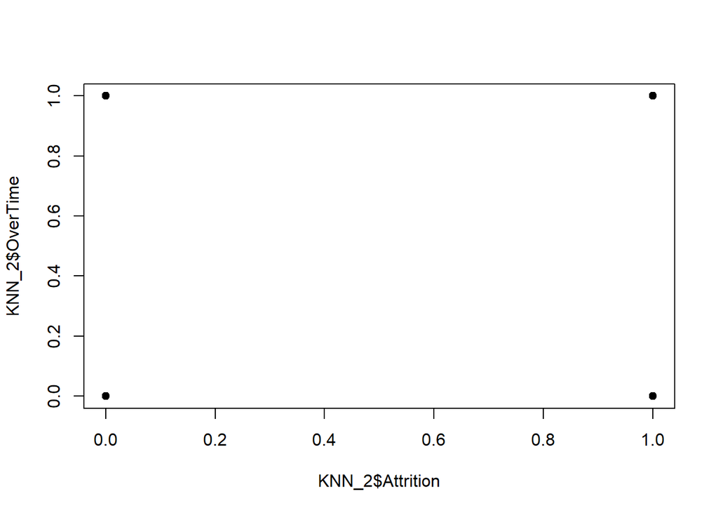

```r
plot(KNN_2$Attrition, KNN_2$OverTime, pch = 19, col = "black")
```

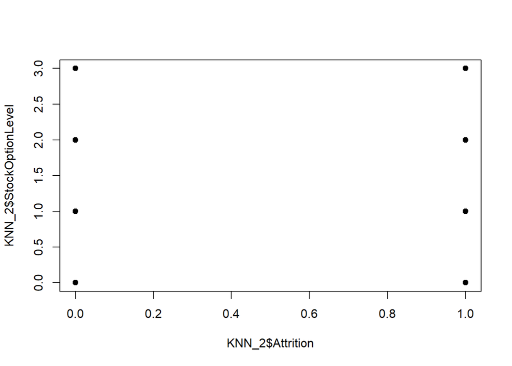

```r
plot(KNN_2$Attrition, KNN_2$StockOptionLevel, pch = 19, col = "black")
```

No significant outliers

7. Correct functional form: The model should be specified correctly (e.g., no omitted or extraneous variables, correct interactions and transformations).

How to check:

Use domain knowledge to ensure that the model specification makes sense. Plot the residuals against each predictor variable or against the predicted values to check for any patterns, which may indicate a missing variable, interaction, or transformation.

Summary: Performing these diagnostic checks will help you determine if the assumptions of linear regression are met in your dataset. If any assumptions are violated, you may need to address the issues by transforming variables, incorporating interaction terms, or considering alternative modeling approaches.

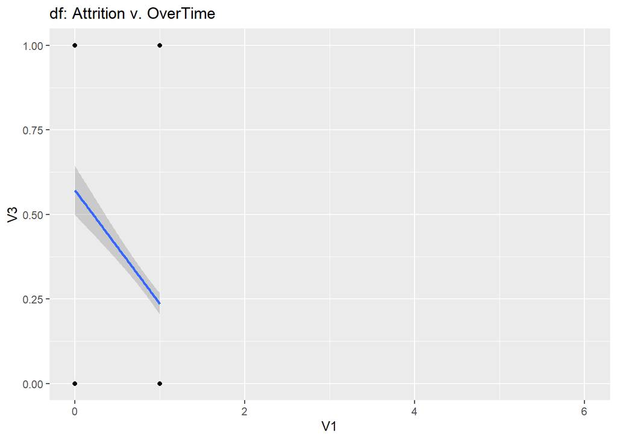

```r
#Recall

df <- as.data.frame(cbind(KNN_2$Attrition, KNN_2$JobInvolvement, KNN_2$OverTime, KNN_2$StockOptionLevel))
#View(df)
df %>% ggplot(aes(x = V1, y = V3)) + geom_point() + ggtitle("df: Attrition v. OverTime") + geom_smooth(method = "lm") + xlim(0,6)
```

```r
# degree 1 model
fit = lm(V1~V3, data = df)
summary(fit)
```

```
##
## Call:
## lm(formula = V1 ~ V3, data = df)
##
## Residuals:
##      Min       1Q   Median       3Q      Max
## -0.90291  0.09709  0.09709  0.09709  0.31746
##
## Coefficients:
##             Estimate Std. Error t value Pr(>|t|)
## (Intercept)  0.90291    0.01424  63.406  < 2e-16 ***
## V3          -0.22037    0.02646  -8.329 3.16e-16 ***
## ---
## Signif. codes:  0 '***' 0.001 '**' 0.01 '*' 0.05 '.' 0.1 ' ' 1
##
## Residual standard error: 0.354 on 868 degrees of freedom
## Multiple R-squared:  0.074,  Adjusted R-squared:  0.07294
## F-statistic: 69.37 on 1 and 868 DF,  p-value: 3.164e-16
```

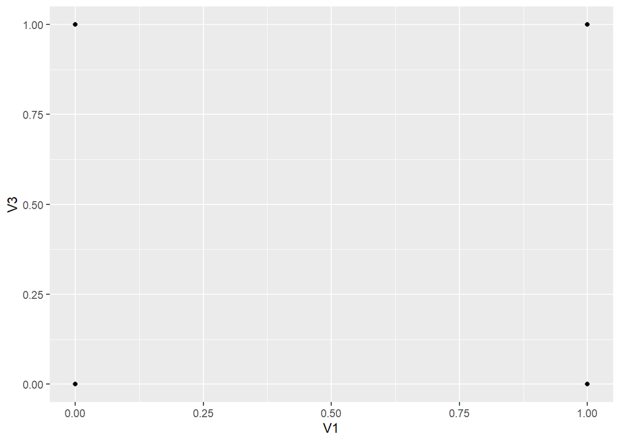

```r
#degree 2 model
df %>% ggplot(aes(x = V1, y = V3)) + geom_point()
```

```r
df2 = df %>% mutate(V_3 = V3^2)
fit = lm(V1~V3+V_3, df2)
summary(fit)
```

```
##
## Call:
## lm(formula = V1 ~ V3 + V_3, data = df2)
##
## Residuals:
##      Min       1Q   Median       3Q      Max
## -0.90291  0.09709  0.09709  0.09709  0.31746
##
## Coefficients: (1 not defined because of singularities)
##             Estimate Std. Error t value Pr(>|t|)
## (Intercept)  0.90291    0.01424  63.406  < 2e-16 ***
## V3          -0.22037    0.02646  -8.329 3.16e-16 ***
## V_3               NA         NA      NA       NA
## ---
## Signif. codes:  0 '***' 0.001 '**' 0.01 '*' 0.05 '.' 0.1 ' ' 1
##
## Residual standard error: 0.354 on 868 degrees of freedom
## Multiple R-squared:  0.074,  Adjusted R-squared:  0.07294
## F-statistic: 69.37 on 1 and 868 DF,  p-value: 3.164e-16
```

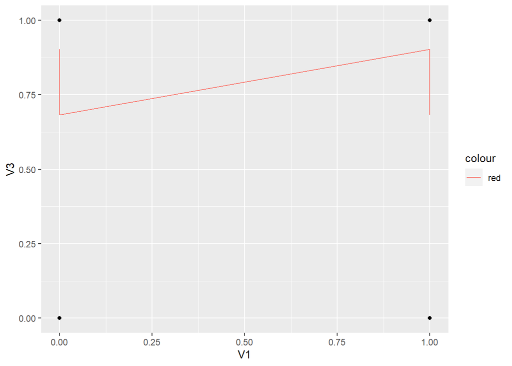

```r
preds = predict(fit)
df2 %>% ggplot(aes(x = V1, y = V3)) + geom_point() +geom_line(data = df2, aes( x = V1, y = preds, col = "red"))
```

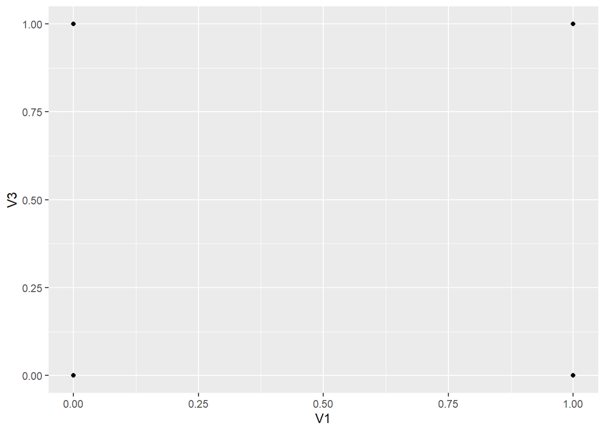

```r
#deg 3 model
df %>% ggplot(aes(x = V1, y = V3)) + geom_point()
```

```r
df3 = df %>% mutate(V_3 = V3^2, V_33 = V3^3)
#View(df3)
fit = lm(V1~V3+V_3+V_33, df3)
summary(fit)
```

```
##
## Call:
## lm(formula = V1 ~ V3 + V_3 + V_33, data = df3)
##
## Residuals:
##      Min       1Q   Median       3Q      Max
## -0.90291  0.09709  0.09709  0.09709  0.31746
##
## Coefficients: (2 not defined because of singularities)
##             Estimate Std. Error t value Pr(>|t|)
## (Intercept)  0.90291    0.01424  63.406  < 2e-16 ***
## V3          -0.22037    0.02646  -8.329 3.16e-16 ***
## V_3               NA         NA      NA       NA
## V_33              NA         NA      NA       NA
## ---
## Signif. codes:  0 '***' 0.001 '**' 0.01 '*' 0.05 '.' 0.1 ' ' 1
##
## Residual standard error: 0.354 on 868 degrees of freedom
## Multiple R-squared:  0.074,  Adjusted R-squared:  0.07294
## F-statistic: 69.37 on 1 and 868 DF,  p-value: 3.164e-16
```

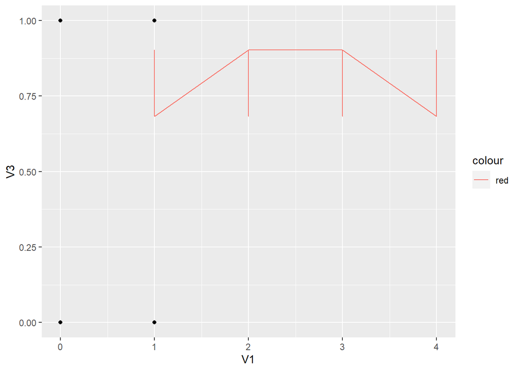

```r
preds = predict(fit)
df3 %>% ggplot(aes(x = V1, y = V3)) + geom_point() +geom_line(data = df3, aes( x = V2, y = preds, col = "red"))
```

OverTime squared or cubed has no effect on Attrition, as we see below.

Call: lm(formula = V1 ~ V3 + V_3 + V_33, data = df3)

Residuals: Min 1Q Median 3Q Max -0.90291 0.09709 0.09709 0.09709 0.31746

Coefficients: (2 not defined because of singularities) Estimate Std. Error t value Pr(>|t|)  
(Intercept) 0.90291 0.01424 63.406 < 2e-16 *V3 -0.22037 0.02646 -8.329 3.16e-16* V_3 NA NA NA NA  
V_33 NA NA NA NA  
— Signif. codes: 0 ‘**’ 0.001 ‘**’ 0.01 ‘’ 0.05 ‘.’ 0.1 ‘ ’ 1

Residual standard error: 0.354 on 868 degrees of freedom Multiple R-squared: 0.074, Adjusted R-squared: 0.07294 F-statistic: 69.37 on 1 and 868 DF, p-value: 3.164e-16

Let’s follow the same analysis on JobInvolvement:

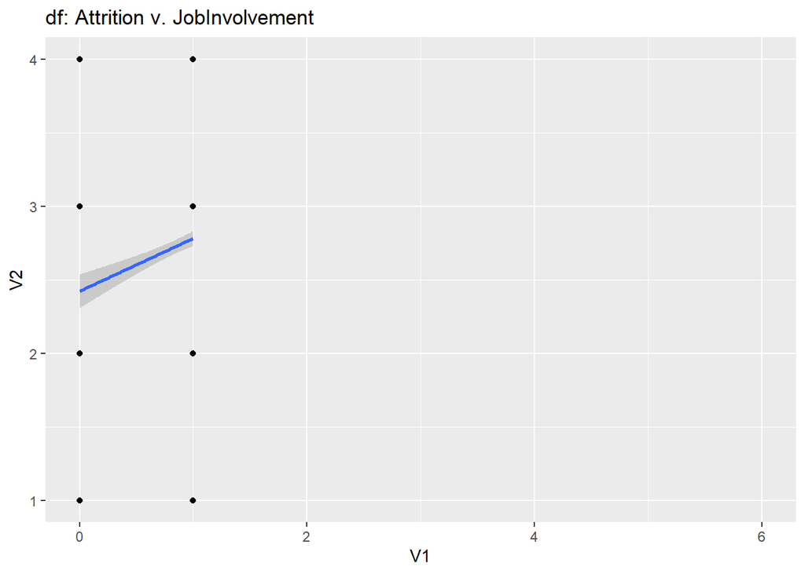

```r
#Recall

df <- as.data.frame(cbind(KNN_2$Attrition, KNN_2$JobInvolvement, KNN_2$OverTime, KNN_2$StockOptionLevel))
#View(df)
df %>% ggplot(aes(x = V1, y = V2)) + geom_point() + ggtitle("df: Attrition v. JobInvolvement") + geom_smooth(method = "lm") + xlim(0,6)
```

```r
# degree 1 model
fit = lm(V1~V2, data = df)
summary(fit)
```

```
##
## Call:
## lm(formula = V1 ~ V2, data = df)
##
## Residuals:
##     Min      1Q  Median      3Q     Max
## -0.9644  0.1337  0.1337  0.1337  0.3300
##
## Coefficients:
##             Estimate Std. Error t value Pr(>|t|)
## (Intercept)  0.57188    0.04899  11.673  < 2e-16 ***
## V2           0.09813    0.01742   5.633 2.39e-08 ***
## ---
## Signif. codes:  0 '***' 0.001 '**' 0.01 '*' 0.05 '.' 0.1 ' ' 1
##
## Residual standard error: 0.3613 on 868 degrees of freedom
## Multiple R-squared:  0.03527,    Adjusted R-squared:  0.03415
## F-statistic: 31.73 on 1 and 868 DF,  p-value: 2.393e-08
```

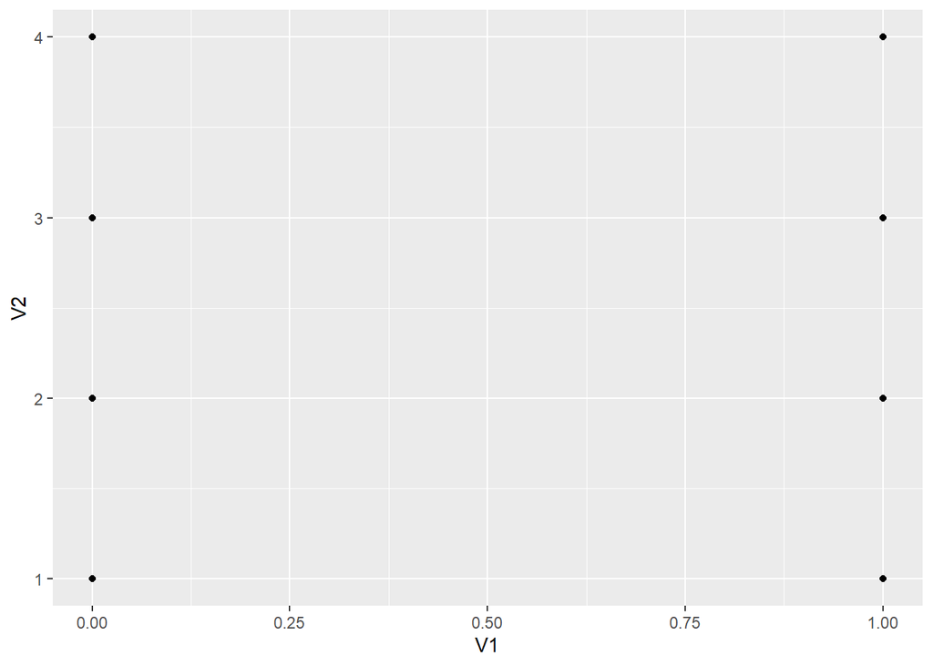

```r
#degree 2 model
df %>% ggplot(aes(x = V1, y = V2)) + geom_point()
```

```r
df_2 = df %>% mutate(V_2 = V2^2) #df_2 is distinct from df2 so we don't get any interaction
fit = lm(V1~V2+V_2, df_2)
summary(fit)
```

```
##
## Call:
## lm(formula = V1 ~ V2 + V_2, data = df_2)
##
## Residuals:
##     Min      1Q  Median      3Q     Max
## -0.8872  0.1179  0.1179  0.1179  0.4226
##
## Coefficients:
##             Estimate Std. Error t value Pr(>|t|)
## (Intercept)  0.27775    0.11462   2.423 0.015589 *
## V2           0.34877    0.09007   3.872 0.000116 ***
## V_2         -0.04910    0.01731  -2.836 0.004676 **
## ---
## Signif. codes:  0 '***' 0.001 '**' 0.01 '*' 0.05 '.' 0.1 ' ' 1
##
## Residual standard error: 0.3599 on 867 degrees of freedom
## Multiple R-squared:  0.04413,    Adjusted R-squared:  0.04193
## F-statistic: 20.02 on 2 and 867 DF,  p-value: 3.179e-09
```

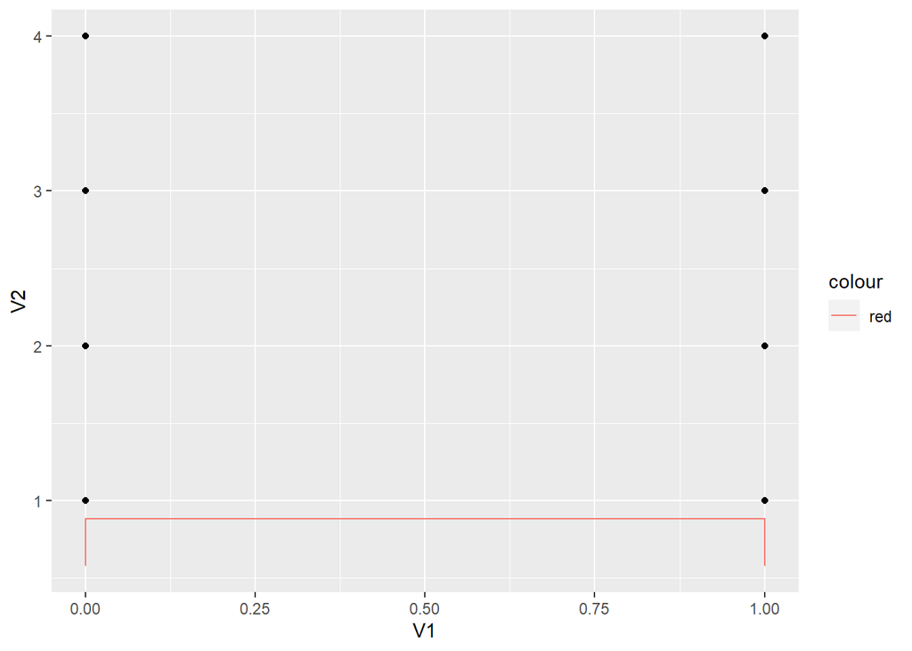

```r
preds = predict(fit)
df_2 %>% ggplot(aes(x = V1, y = V2)) + geom_point() +geom_line(data = df_2, aes( x = V1, y = preds, col = "red"))
```